# Nhóm 3: Transformation - Biến đổi biến

**Danh sách thành viên nhóm:**

- 22C01006 - Nguyễn Thị Phương Hảo
- 22C01030 - Tôn Thiện Minh Anh
- 22C01031 - Lê Hoàng Đức
- 22C01034 - Đào Thị Minh Lý
- 22C01035 - Chu Thị Bảo Ngọc

**Phân công công việc:**

- Power Transformation : Tôn Anh
- Box - Cox Method : Hoàng Đức, Phương Hảo
- Yeo-Johnson Method : Minh Lý
- Phương pháp tiếp cận tổng quát cho quy trình biến đổi biến: Bảo Ngọc
- Demo : Phương Hảo

**Phân chia thuyết trình:**

- Tôn Anh: Introduction + Power Transformation
- Hoàng Đức: Box - Cox Method
- Minh Lý: Yeo-Johnson Method
- Bảo Ngọc: Phương pháp tiếp cận tổng quát cho quy trình biến đổi biến
- Phương Hảo: Demo full dataset

# Nội dung thuyết trình:

1. Giới thiệu về biến đổi biến
2. Các phương pháp:
- Biến đổi lũy thừa (power transformation)
- Phương pháp Box - Cox
- Phương pháp Yeo-Johnson
- Phương pháp tiếp cận tổng quát cho quy trình biến đổi biến
3. Demo

# 1. Giới thiệu về biến đổi biến

**Định nghĩa:**

> Biến đổi biến là việc dùng một hàm toán học/phương pháp để thay đổi giá trị của biến trở nên phù hợp hơn.

**Nguyên nhân phải biến đổi?**

$Y_{i} = \beta_{0} + \beta_{1}x_{i} + \varepsilon_{i}$ trong đó $\varepsilon_{i} \quad i.i.d \sim \mathcal{N}(0, \sigma^{2})$

Mô hình hồi quy có các giả định sau:

1. Y và biến X có mối quan hệ tuyến tính.
2. Không có hiện tượng đa cộng tuyến giữa các biến $X_{i}$
3. Các giả định về sai số ngẫu nhiên:
- Các sai số $\varepsilon_{i}$ độc lập với nhau:
  $$Cov(\varepsilon_{i},
  \varepsilon_{j}) \neq 0 \qquad \forall i \neq j$$
- $\mathbb{E}(\varepsilon_{i}) = 0$ và $\mathbb{Var}(\varepsilon_{i}) = \sigma^{2}$
- Các sai số có phân phối chuẩn.

**Tuy nhiên, trong nhiều trường hợp, các giả định này không phải lúc nào cũng thỏa.**

> Mục đích của thực hiện biến đổi biến là để **làm thỏa mãn các giả định hồi quy**, tăng khả năng dự báo và chất lượng của mô hình.

# 2. Các phương pháp

## 2.1. Biến đổi lũy thừa (Power Transformation)

> Là phương pháp sử dụng các hàm lũy thừa để biến đổi X và/hoặc Y

Ví dụ: Thay vì $X$ hoặc $Y$ thì biến đổi thành $X^{\lambda}$ hoặc $Y^{\lambda}$

- Khi $\lambda = 1$: Không có biến đổi
- Khi $\lambda = -1$: $\dfrac{1}{X}$
- Khi $\lambda = 0.5$: $\sqrt{X}$
- Khi $\lambda = 0$: $log(X)$

#### Ví dụ 1: Mammals

```r
library("MASS")
mammals
```

```
##                               body   brain
## Arctic fox                   3.385   44.50
## Owl monkey                   0.480   15.50
## Mountain beaver              1.350    8.10
## Cow                        465.000  423.00
## Grey wolf                   36.330  119.50
## Goat                        27.660  115.00
## Roe deer                    14.830   98.20
## Guinea pig                   1.040    5.50
## Verbet                       4.190   58.00
## Chinchilla                   0.425    6.40
## Ground squirrel              0.101    4.00
## Arctic ground squirrel       0.920    5.70
## African giant pouched rat    1.000    6.60
## Lesser short-tailed shrew    0.005    0.14
## Star-nosed mole              0.060    1.00
## Nine-banded armadillo        3.500   10.80
## Tree hyrax                   2.000   12.30
## N.A. opossum                 1.700    6.30
## Asian elephant            2547.000 4603.00
## Big brown bat                0.023    0.30
## Donkey                     187.100  419.00
## Horse                      521.000  655.00
## European hedgehog            0.785    3.50
## Patas monkey                10.000  115.00
## Cat                          3.300   25.60
## Galago                       0.200    5.00
## Genet                        1.410   17.50
## Giraffe                    529.000  680.00
## Gorilla                    207.000  406.00
## Grey seal                   85.000  325.00
## Rock hyrax-a                 0.750   12.30
## Human                       62.000 1320.00
## African elephant          6654.000 5712.00
## Water opossum                3.500    3.90
## Rhesus monkey                6.800  179.00
## Kangaroo                    35.000   56.00
## Yellow-bellied marmot        4.050   17.00
## Golden hamster               0.120    1.00
## Mouse                        0.023    0.40
```

[output cut: 8 more lines]

```
## Desert hedgehog              0.550    2.40
## Giant armadillo             60.000   81.00
## Rock hyrax-b                 3.600   21.00
## Raccoon                      4.288   39.20
## Rat                          0.280    1.90
## E. American mole             0.075    1.20
## Mole rat                     0.122    3.00
## Musk shrew                   0.048    0.33
## Pig                        192.000  180.00
## Echidna                      3.000   25.00
## Brazilian tapir            160.000  169.00
## Tenrec                       0.900    2.60
## Phalanger                    1.620   11.40
## Tree shrew                   0.104    2.50
## Red fox                      4.235   50.40
```

Vẽ thử biểu đồ, ta cảm thấy rằng ngoại trừ 3 quan trắc của người và 2 loài voi thì còn lại đều nằm ở góc dưới bên trái của biểu đồ gây khó cho việc quan sát và tìm ra các thông tin hữu ích.

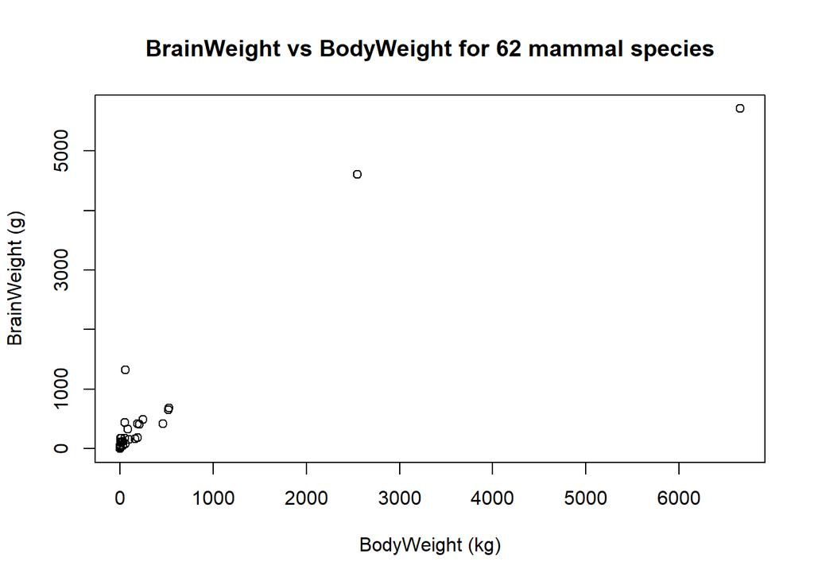

```r
attach(mammals)
plot(brain ~ body, xlab = "BodyWeight (kg)",
     ylab = "BrainWeight (g)",
     main = "BrainWeight vs BodyWeight for 62 mammal species")
```

Lúc này, việc sử dụng biến đổi lũy thừa có thể sẽ có ích.

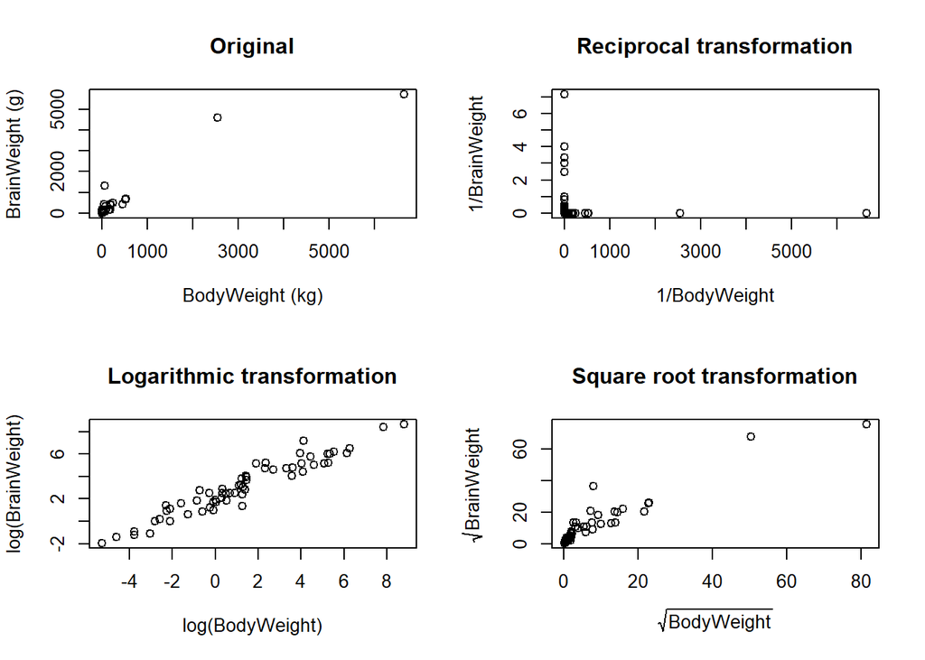

```r
par(mfrow = c (2, 2))

# Original plot
plot(brain ~ body, xlab = "BodyWeight (kg)",
     ylab = "BrainWeight (g)",
     main="Original")

# Lambda = -1
plot((1/brain) ~ (1/body), xlab = "1/BodyWeight",
     ylab="1/BrainWeight",
     main="Reciprocal transformation")

# Lambda = 0
plot(log(brain) ~ log(body), xlab = "log(BodyWeight)",
     ylab="log(BrainWeight)",
     main="Logarithmic transformation")

# Lambda = 0.5
plot(sqrt(brain) ~ sqrt(body), xlab = expression(sqrt(BodyWeight)),
     ylab=expression(sqrt(BrainWeight)),
     main="Square root transformation")
```

### Quy tắc thực nghiệm trong mô hình hồi quy tuyến tính

**1. Quy tắc log:**

> Nếu phạm vi giá trị của một biến lớn hơn một **bậc độ lớn (order of magnitude)** và biến hoàn toàn dương thì việc thay thế biến bằng giá trị logarit của nó **có thể** sẽ hữu ích.

Ví dụ: Giá trị của biến X nằm trong khoảng [a, b] với b lớn gấp $10^{k}$ lần a thì $k$ ở đây chính là bậc độ lớn (order of magnitude)

Trong trường hợp bộ dữ liệu mammals, ta thấy rằng các biến đều thỏa quy tắc thực nghiệm 1 - quy tắc log. Chính vì vậy, trong số các phép biến đổi thực hiện, phép biến đổi logarit cho kết quả khả quan nhất.

```r
summary(mammals)
```

```
##       body              brain
##  Min.   :   0.005   Min.   :   0.14
##  1st Qu.:   0.600   1st Qu.:   4.25
##  Median :   3.342   Median :  17.25
##  Mean   : 198.790   Mean   : 283.13
##  3rd Qu.:  48.202   3rd Qu.: 166.00
##  Max.   :6654.000   Max.   :5712.00
```

**2. Quy tắc phạm vi:**

> Nếu phạm vi của một biến nhỏ hơn đáng kể so với một bậc độ lớn thì bất kỳ phép biến đổi nào cho biến đó dường như sẽ không hữu ích.

#### Ví dụ 2: Biến đổi để ổn định phương sai.

```r
library(readr)
initech <- read_csv("initech.csv")
attach(initech)
head(initech)
```

```
## # A tibble: 6 × 2
##   years salary
##   <dbl>  <dbl>
## 1     1  41504
## 2     1  32619
## 3     1  44322
## 4     2  40038
## 5     2  46147
## 6     2  38447
```

Đây là một bộ dữ liệu giả định về mức lương của nhân viên theo thâm niên.

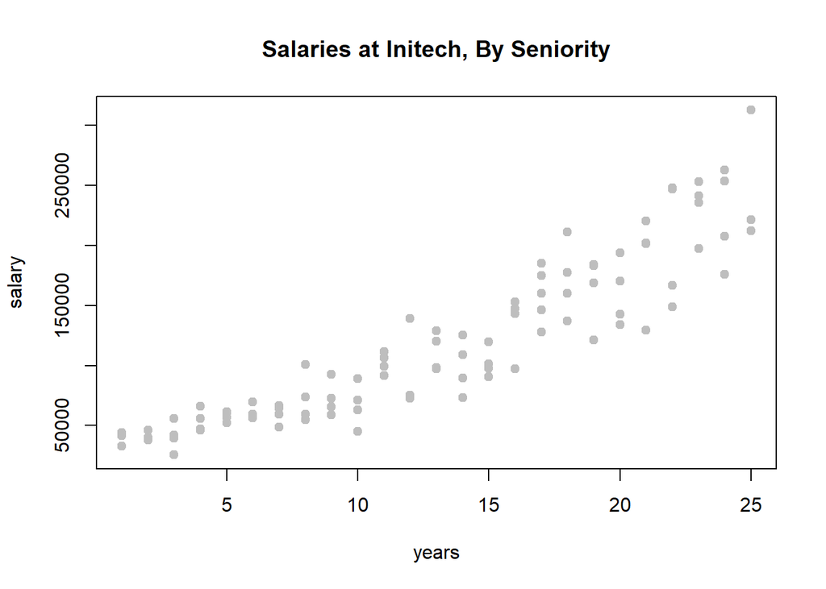

```r
plot(salary ~ years, data = initech, col = "grey",
     pch = 20, cex = 1.5,
     main = "Salaries at Initech, By Seniority")
```

Fit thử mô hình hồi quy

```r
model = lm(salary ~ years, data = initech)
summary(model)
```

```
##
## Call:
## lm(formula = salary ~ years, data = initech)
##
## Residuals:
##    Min     1Q Median     3Q    Max
## -57225 -18104    241  15589  91332
##
## Coefficients:
##             Estimate Std. Error t value Pr(>|t|)
## (Intercept)     5302       5750   0.922    0.359
## years           8637        389  22.200   <2e-16 ***
## ---
## Signif. codes:  0 '***' 0.001 '**' 0.01 '*' 0.05 '.' 0.1 ' ' 1
##
## Residual standard error: 27360 on 98 degrees of freedom
## Multiple R-squared:  0.8341, Adjusted R-squared:  0.8324
## F-statistic: 492.8 on 1 and 98 DF,  p-value: < 2.2e-16
```

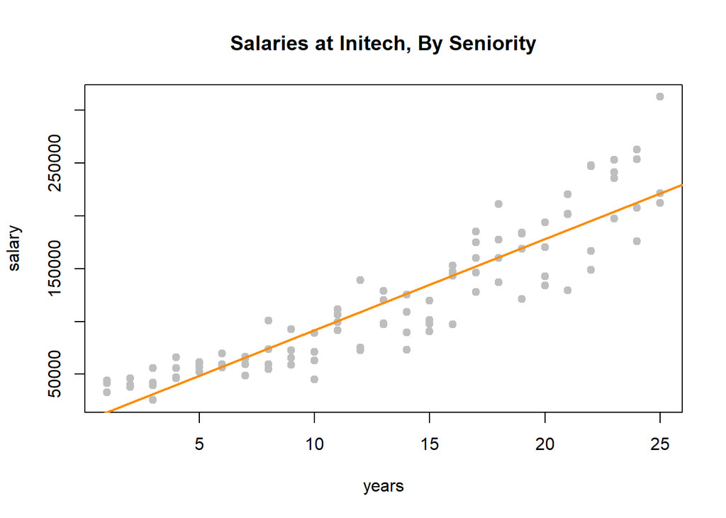

```r
plot(salary ~ years, data = initech, col = "grey",
     pch = 20, cex = 1.5,
     main = "Salaries at Initech, By Seniority")
abline(model, col = "darkorange", lwd = 2)
```

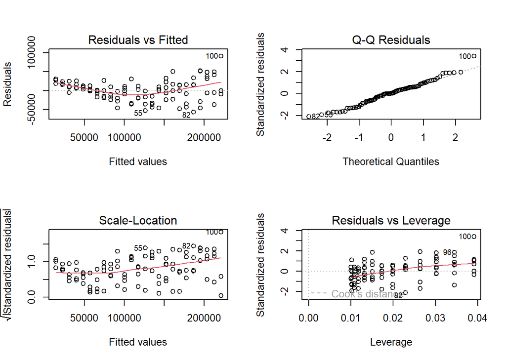

```r
par(mfrow = c(2, 2))
plot(model)
```

**Nhận xét:**

- Đối với biểu đồ fitted vs residuals, nếu đường màu đỏ nằm ngang và gần đường thẳng y = 0 nghĩa là giả định về kỳ vọng của sai số luôn bằng 0 thỏa mãn. Tuy nhiên, theo quan sát, ta thấy rằng có vẻ như giả định này hiện tại đang không thỏa.
- Ngoài ra, trong biểu đồ Scaled-Location, đường thẳng màu đỏ không nằm ngang và các điểm cũng không nằm phân bố đều xung quanh đường màu đỏ. Điều này có nghĩa là giả định về tính ổn định của phương sai cũng đang không thỏa.

Do ví dụ này tập trung vào việc biến đổi để ổn định phương sai, ta thực hiện kiểm định để xem rõ hơn về giả thiết này:

- H0: Phương sai của sai số không đổi.
- H1: Phương sai của sai số thay đổi.

```r
library(car)
ncvTest(model)
```

```
## Non-constant Variance Score Test
## Variance formula: ~ fitted.values
## Chisquare = 19.49124, Df = 1, p = 1.0106e-05
```

Kết quả cho thấy rằng p-value rất nhỏ < 0.05 nên ta sẽ bác bỏ H0. Như vậy, trong trường hợp này, phương sai của sai số thay đổi nên ta sẽ thực hiện thử phép biến đổi để ổn định phương sai.

Vận dụng quy tắc thực nghiệm cho mô hình hồi quy tuyến tính - quy tắc logarit, biến đổi $Y$ thành $log(Y)$

```r
summary(initech)
```

```
##      years        salary
##  Min.   : 1   Min.   : 25597
##  1st Qu.: 7   1st Qu.: 60072
##  Median :13   Median : 98561
##  Mean   :13   Mean   :117578
##  3rd Qu.:19   3rd Qu.:166981
##  Max.   :25   Max.   :312549
```

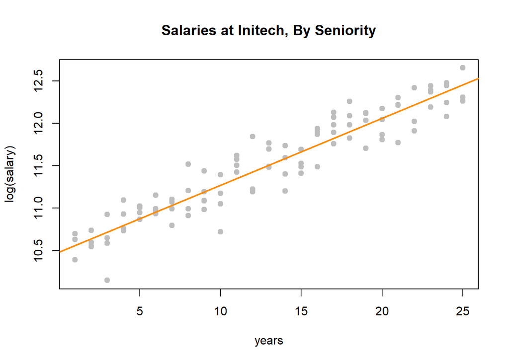

```r
model_log = lm(log(salary) ~ years, data=initech)
plot(log(salary) ~ years, data = initech, col = "grey",
     pch = 20, cex = 1.5,
     main = "Salaries at Initech, By Seniority")
abline(model_log, col = "darkorange", lwd = 2)
```

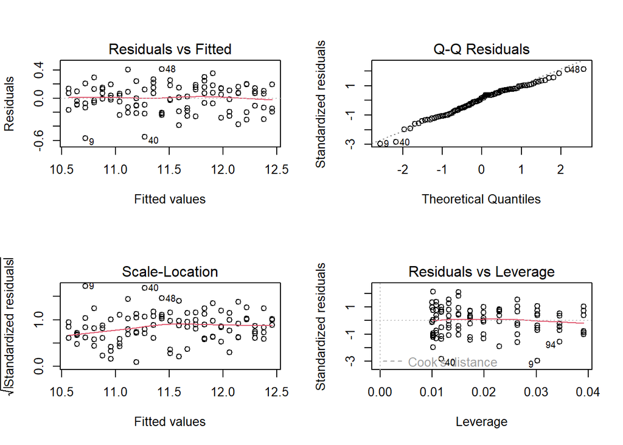

```r
par(mfrow = c(2, 2))
plot(model_log)
```

Thực hiện kiểm định về tính ổn định của phương sai cho mô hình sau khi biến đổi biến

- H0: Phương sai của sai số không đổi.
- H1: Phương sai của sai số thay đổi.

```r
ncvTest(model_log)
```

```
## Non-constant Variance Score Test
## Variance formula: ~ fitted.values
## Chisquare = 6.3605e-06, Df = 1, p = 0.99799
```

Kết quả cho thấy rằng p-value = 0.99799 nên ta sẽ chấp nhận H0. Như vậy, sau khi thực hiện biến đổi, giả thiết về tính ổn định phương sai của mô hình hồi quy đã thỏa mãn.

## 2.2. Box-Cox

**2.2.1. Transforming Only the Predictor Variable**

Để lựa chọn phép biến đổi phù hợp cho Transforming Only the Predictor Variable, ta sử dụng các scaled powers transformation cho biến X dương được định nghĩa như sau :

$$\psi(X,\lambda) = \begin{cases} (X^\lambda
- 1)/\lambda & \text{$\lambda \neq 0$} \\ log(X) &
\text{$\lambda = 0$} \end{cases}$$

Trong đó :  
$\psi(X,\lambda)$ là một hàm liên tục theo $\lambda$

Nếu chỉ biến đổi dự đoán và sử dụng một lựa chọn từ power family, chúng ta bắt đầu với hàm trung bình

$$E[Y\|X] = β₀ + β₁ψS(λ, X)$$

Sử dụng tập dữ liệu ufcwc. Xem xét sự phụ thuộc của chiều cao cây (**Height**) tính bằng **decimet** trên **Dbh**, đường kính của cây tính bằng milimét ở độ cao 137 cm so với mặt đất, cho một mẫu cây tuyết tùng tây trong khu vực Upper Flat Creek của Rừng Thử Nghiệm Đại học Idaho vào năm 1991.

```r
library(alr3)
library(extras)
library(car)
library(MASS)
```

```r
#ufcwc <- read.table("ufcwc.txt")
head(ufcwc)
```

```
##   Plot Tree Species Dbh Height
## 1    3    5      WC 360    207
## 2    3    8      WC 380    225
## 3    4    1      WC 460    180
## 4    6    2      WC 290    220
## 5    6    3      WC 294    320
## 6    6    4      WC 685    260
```

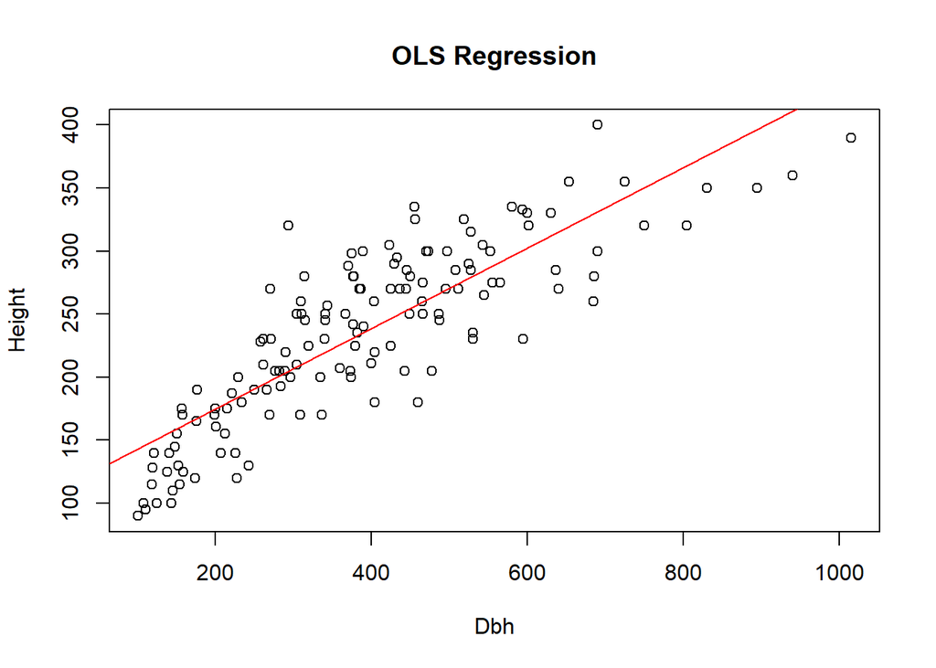

```r
model <- lm(Height ~ Dbh, data = ufcwc)

# Plotting the OLS regression line with log(dbh) on the x-axis
plot(ufcwc$Dbh, ufcwc$Height, main = "OLS Regression", xlab = "Dbh", ylab = "Height")
abline(model, col = "red")
```

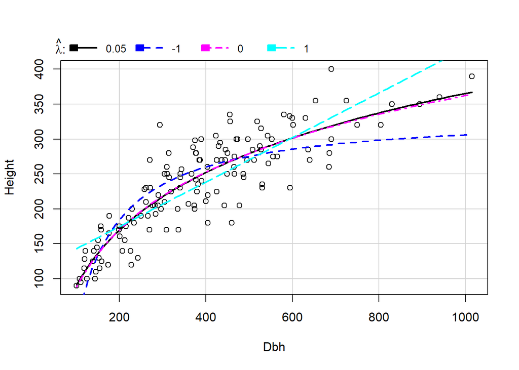

```
##        lambda      RSS
## 1  0.04787804 152122.8
## 2 -1.00000000 197352.2
## 3  0.00000000 152232.3
## 4  1.00000000 193739.7
```

```r
with(ufcwc, invTranPlot(Dbh, Height))
```

```r
unlist(with(ufcwc, invTranEstimate(Dbh,Height)))
```

```
##      lambda     lowerCI     upperCI
##  0.04787804 -0.16395064  0.25752601
```

```r
#??invTranEstimate
#??bcPower
```

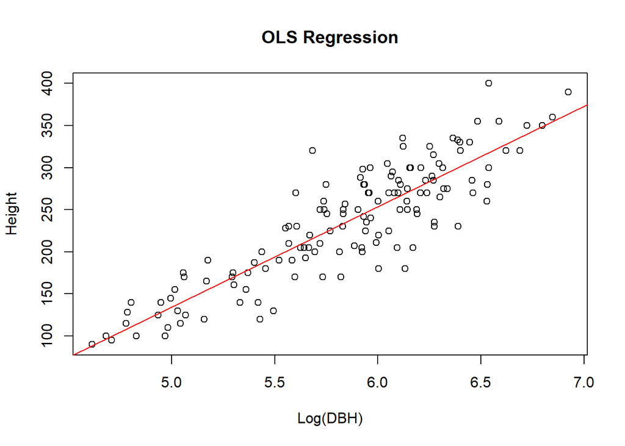

```r
model <- lm(Height ~ log(Dbh), data = ufcwc)

# Plotting the OLS regression line with log(dbh) on the x-axis
plot(log(ufcwc$Dbh), ufcwc$Height, main = "OLS Regression", xlab = "Log(DBH)", ylab = "Height")
abline(model, col = "red")
```

### 2.2.2. Phương pháp Box-cox

Box và Cox (1964) đã cung cấp một phương pháp tổng quát để lựa chọn một phép transform thông qua tham số $\lambda$ được gọi là phương pháp box-cox. Phương pháp này thường được sử dụng để đưa ra lựa chọn phép biến đổi cho response variable. Tuy vậy, nó cũng có thể được sử dụng để hổ trợ đưa ra lựa chọn phép biến đổi cho các predictor variables.

$$\begin{align*}
\psi(Y, \lambda_y) &= \psi_S(Y,\lambda_y) \times
\text{gm}(Y)^{1-\lambda_y} \\
&= \begin{cases}
\text{gm}(Y)^{1-\lambda_y} \times \left(\frac{Y^{\lambda_y}
-1}{\lambda_y}\right) & \text{nếu } \lambda_y \neq 0 \\
\text{gm}(Y) \times \log(Y) & \text{nếu } \lambda_y = 0
\end{cases}
\end{align*}$$

Trong đó, :

- $gm(Y)$ là geometric mean của biến chưa được transform với $gm(Y) = \exp{(\sum log(y_i/n))}$

Giả sử có hàm trung bình cho $\lambda_y$ :
$$E(\psi_M(Y,\lambda_y)| X = x) = \beta \text{'}x$$
Nếu $λ_y$ được biết trước, chúng ta có thể điều chỉnh hàm trung bình bằng OLS vì transform response $ψ_M(Y, λ_y)$ sẽ hoàn toàn được xác định. Việc nhân scaled transformation với $gm(Y)^{1−λ}$ đảm bảo rằng đơn vị của $ψ_M(Y, λ_y)$ là như nhau cho tất cả các giá trị của $λ_y$, và do đó tất cả các $RSS(λy)$ đều có cùng đơn vị. Chúng ta ước lượng $λ_y$ để là giá trị của tham số biến đổi mà làm giảm thiểu $RSS(λ_y)$.

Từ một góc độ thực tế, chúng ta có thể lựa chọn $λ_y$ từ $λ_y$ $∈ \text{{−1, −1/2, 0, 1/3, 1/2, 1}}$ một lần nữa.

#### Lưu ý :

- Phương pháp Box-Cox không biến đổi để tạo ra tính tuyến tính (linearity), mà thay vào đó, nó biến đổi để tạo ra tính chuẩn (normality): $λ$ được chọn để làm cho residuals từ phương trình hồi quy của $ψ(Y, λ_y)$ trên $X$ gần như phân phối theo phân phối chuẩn nhất có thể (as close to normally distributed as possible).

**Xét ví dụ** : cho tập dữ liệu Highway Accident tỷ lệ tai nạn ô tô trong số vụ tai nạn trên một triệu dặm xe với một số yếu tố dự báo tiềm năng bao gồm các quan trắc :

| Variable | Description |
| --- | --- |
| rate | 1973 accident rate per million vehicle miles |
| len | Length of the segment in miles |
| adt | Estimated average daily traffic count in thousands |
| trucks | Truck volume as a percentage of the total volume |
| slim | 1973 speed limit |
| shld | Shoulder width in feet of outer shoulder on the roadway |
| sigs | Number of signalized interchanges per mile in the segment |

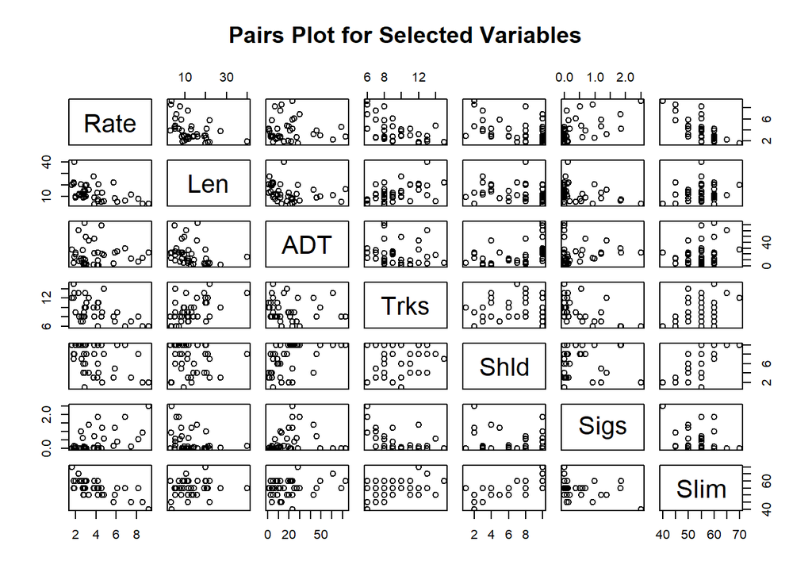

```r
vars_to_plot <- c("Rate","Len", "ADT", "Trks", "Shld", "Sigs","Slim")
pairs(highway[, vars_to_plot], main = "Pairs Plot for Selected Variables")
```

```r
highway$Sigs1 <- with(highway, (Sigs * Len + 1)/Len)
summary(a1 <- powerTransform(cbind(Len, ADT, Trks, Shld, Sigs1) ~ 1, highway))
```

```
## bcPower Transformations to Multinormality
##       Est Power Rounded Pwr Wald Lwr Bnd Wald Upr Bnd
## Len      0.1437           0      -0.2732       0.5607
## ADT      0.0509           0      -0.1854       0.2872
## Trks    -0.7028           0      -1.9134       0.5078
## Shld     1.3456           1       0.6341       2.0570
## Sigs1   -0.2408           0      -0.5341       0.0525
##
## Likelihood ratio test that transformation parameters are equal to 0
##  (all log transformations)
##                                    LRT df      pval
## LR test, lambda = (0 0 0 0 0) 23.32447  5 0.0002926
##
## Likelihood ratio test that no transformations are needed
##                                    LRT df       pval
## LR test, lambda = (1 1 1 1 1) 132.8574  5 < 2.22e-16
```

Test 1 : Likelihood ratio test that transformation parameters are equal to 0 (all log transformations)

$H_0$: Cần thực hiện phép biến đổi log-transformation cho tất cả các biến

$H_1$ : Không thực hiện phép biến đổi log-transformation cho tất cả các biến.

- Kết luận : bác bỏ $H_0$ do p_val =0.0002926< 0.05

Test 2: Likelihood ratio test that no transformation are needed

$H_0$: Không cần thực hiện phép transformation

$H_1$: Cần thực hiện tối thiểu một phép transformation

- Kết luận : bác bỏ $H_0$ do p_val = 2.22e-16 < 0.05

```r
testTransform(a1, c(0,0,0,1,0))
```

```
##                                    LRT df    pval
## LR test, lambda = (0 0 0 1 0) 6.088599  5 0.29769
```

$H_0$ : Phép transformation sử dụng các giá trị lambda là không cần thiết

$H_1$ : Phép transformation sử dụng các giá trị lambda là cần thiết

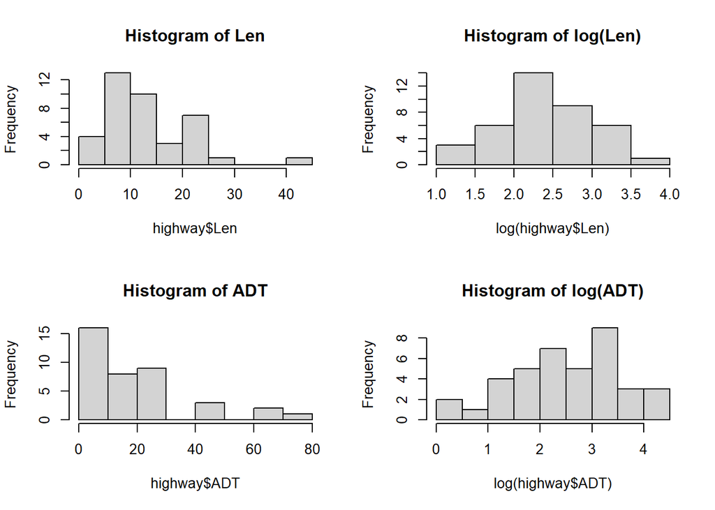

```r
par(mfrow = c(2, 2))

# Plot histograms for Len and log(Len)
hist(highway$Len, main = "Histogram of Len")
hist(log(highway$Len),  main = "Histogram of log(Len)")

# Plot histograms for ADT and log(ADT)
hist(highway$ADT, main = "Histogram of ADT")
hist(log(highway$ADT), main = "Histogram of log(ADT)")
```

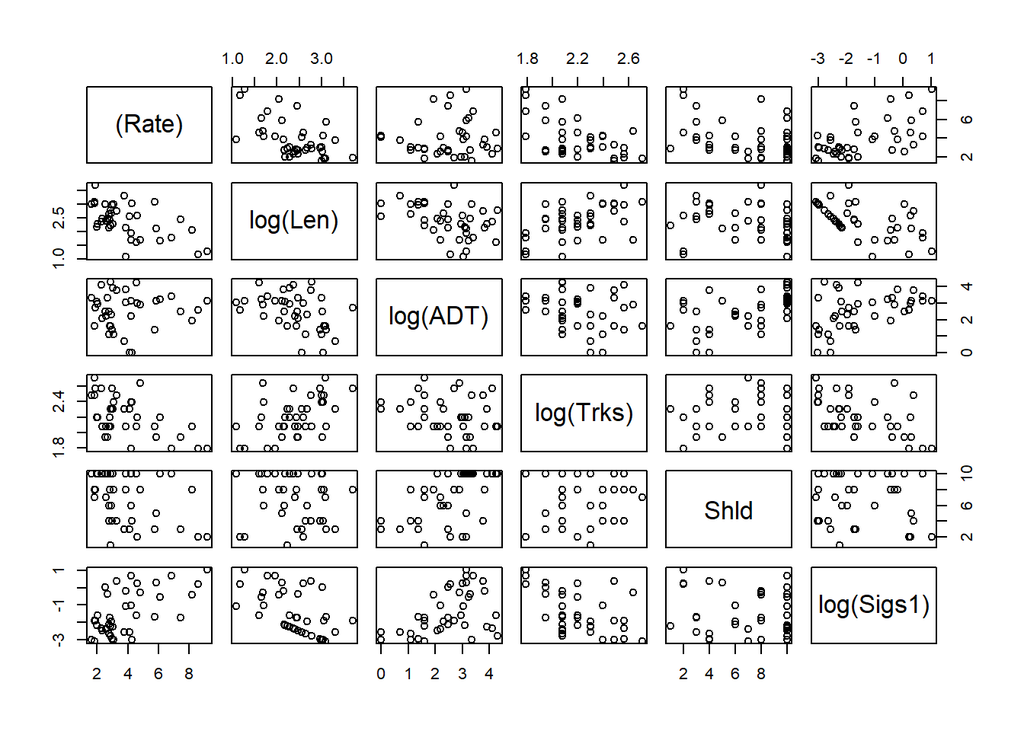

```r
pairs((Rate)~log(Len) + log(ADT) + log(Trks) + Shld + log(Sigs1), highway)
```

## 2.3. Phương pháp Yeo-Johnson

Giống với phép biến đổi Box-Cox, phép biến đổi Yeo-Johnson cũng được đặt tên theo 2 tác giả. Phép biến đổi Yeo-Johnson hoạt động tương tự như phép biến đổi Box-Cox. Cơ bản, phép biến đổi Yeo-Johnson cũng điều chỉnh phân phối của biến số về gần với phân phối Gauss hơn, giúp đồng nhất phương sai và tăng khả năng ứng dụng mô hình hồi quy tuyến tính. Điểm khác biệt của phép biến đổi này là có thể thực hiện trên dữ liệu có số âm và dữ liệu có phương sai thấp hoặc bằng 0. Điều này giúp cải thiện khả năng dự đoán và tối ưu hóa mô hình hồi quy.

Công thức Yeo-Johnson được định nghĩa như sau:

$\Psi(y,\lambda) = \begin{cases} \left((y + 1)^{\lambda} - 1\right)/\lambda & \text{if } \lambda \neq 0, y \geq 0 \\ \log(y + 1) & \text{if } \lambda = 0, y \geq 0 \\ -\left((-y + 1)^{2 - \lambda} - 1\right)/(2 - \lambda) & \text{if } \lambda \neq 2, y < 0 \\ -\log(-y + 1) & \text{if } \lambda = 2, y < 0 \end{cases}$

Trong đó:

$y$ là giá trị dữ liệu ban đầu.

$\lambda$ là một tham số có thể được ước lượng từ dữ liệu để tối ưu hóa phân phối biến số. $\lambda$ có thể nhận giá trị bất kỳ trong khoảng từ âm vô cùng đến dương vô cùng.

Nếu $y$ dương nghiêm ngặt, thì phép biến đổi Yeo-Johnson sẽ giống với phép biến đổi Box-Cox của $(y + 1)$. Nếu $y$ âm nghiêm ngặt, thì phép biến đổi Yeo-Johnson sẽ giống với phép biến đổi Box-Cox của $(- y + 1)$, nhưng với số mũ $(2 - \lambda)$. Khi có cả giá trị âm và dương, phép biến đổi là sự kết hợp của hai phép biến đổi trên, với việc sử dụng các số mũ khác nhau cho các giá trị âm và dương.

### Ví dụ

Dữ liệu tự tạo với 5 biến (x1, x2, x3, x4, y) và 30 quan trắc.

```r
my_data <- read.csv("my_data.csv")
dim(my_data)
```

```
## [1] 30  5
```

```r
my_data
```

```
##    x1 x2 x3 x4         y
## 1   3  4 17  9 15.299740
## 2   3  1 16  3 18.187333
## 3  10  5  1  6  7.832611
## 4   2 -1  3  3  5.464300
## 5   6  1 12 -8 13.273579
## 6   5 -1  4 -3  7.289593
## 7   4  5 18  3 17.156884
## 8   6  0 19  8 19.953308
## 9   9  3 13  4 15.652457
## 10 10 -4  2  6  8.848381
## 11  5 -1  7  0 10.354972
## 12  3  2 15 -4 14.115096
## 13  9 -4 11  4 14.832058
## 14  9 -5 13 -5 18.019773
```

[output cut: 16 more lines]

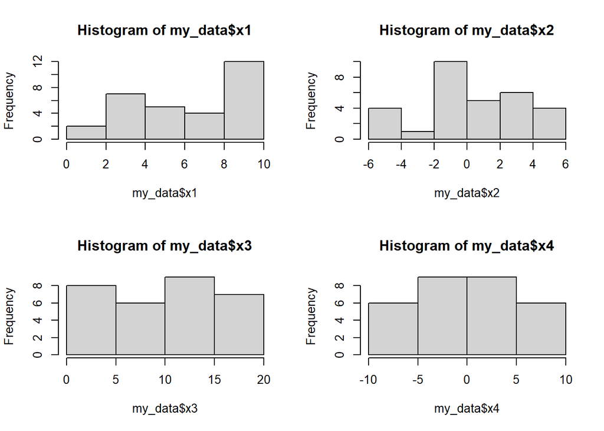

```r
par(mfrow = c(2, 2))

hist(my_data$x1)
hist(my_data$x2)

hist(my_data$x3)
hist(my_data$x4)
```

Với 4 biểu đồ trên, các biến x1, x2, x3 đang không có phân phối gần bằng với phân phối chuẩn. Nên cần thực hiện phép biến đổi trên 3 biến này.

```r
# summary(a1 <- powerTransform(cbind(x1, x2, x3, x4) ~ 1, my_data))

# Error in bc1(out[, j], lambda[j]) :
#  First argument must be strictly positive.
```

Nếu chỉ sử dụng hàm powerTransform tương tự như trên, thì với bộ dữ liệu này, sẽ trả về lỗi. Bởi vì nếu không thêm tham số family cho hàm powerTransform, thì máy sẽ tự động hiểu là Box-Cox. Mà Box-Cox chỉ sử dụng với dữ liệu hoàn toàn dương, nhưng bộ dữ liệu này có cả số âm và số 0, nên sẽ gây ra lỗi.

Do đó, ứng với bộ dữ liệu có cả số âm, số 0, và số dương; ta sẽ thêm family = ‘yjPower’ vào hàm powerTransform.

```r
a1 <- powerTransform(cbind(x1, x2, x3, x4) ~ 1, my_data, family = 'yjPower')
summary(a1)
```

```
## yjPower Transformations to Multinormality
##    Est Power Rounded Pwr Wald Lwr Bnd Wald Upr Bnd
## x1    1.1215           1       0.1518       2.0911
## x2    1.1029           1       0.8326       1.3731
## x3    0.7172           1       0.0998       1.3345
## x4    0.9948           1       0.7826       1.2069
##
##  Likelihood ratio test that all transformation parameters are equal to 0
##                                  LRT df       pval
## LR test, lambda = (0 0 0 0) 132.9848  4 < 2.22e-16
```

$H_1$: Cần thực hiện ít nhất một phép transformation

```r
testTransform(a1, c(1,1,1,0))
```

```
##                                  LRT df       pval
## LR test, lambda = (1 1 1 0) 65.31923  4 2.2038e-13
```

$H_0$ : Thực hiện phép transformation với $\lambda = 0$ cho biến x4 là cần thiết

$H_1$ : Thực hiện phép transformation với $\lambda = 0$ cho biến x4 là không cần thiết

Kết luận: Bác bỏ $H_0$ vì p-value nhỏ => Thực hiện phép transformation với $\lambda = 0$ cho biến x4 là không cần thiết

### Kiểm định điều kiện của mô hình hồi quy tuyến tính

```r
yeo_johnson_transform <- function(data, lambdas, columns) {
  transformed_data <- data

  for (col in columns) {
    # Extract the column data
    x <- data[[col]]
    lambda <- lambdas[[col]]
    eps <- .5

    # Perform Yeo-Johnson transformation
    pos_idx <- which(x >= 0)
    neg_idx <- which(x < 0)

    # Transform negative values
    if (length(pos_idx)>0) {
      if (abs(lambda) < eps) {
        x[pos_idx] <- log(x[pos_idx] + 1)
      } else {
        x[pos_idx] <- ((x[pos_idx] + 1) ^ lambda - 1) / lambda
      }
    }

    # Transform nonnegative values
    if (length(neg_idx)>0){
      if (abs(lambda - 2) < eps) {
        x[neg_idx] <- - log(-x[neg_idx] + 1)
      } else {
        x[neg_idx] <- - ((-x[neg_idx] + 1) ^ (2 - lambda) - 1) / (2 - lambda)
      }
    }

    # Assign the transformed column back to the data
    transformed_data[[col]] <- x
  }

  return(transformed_data)
}


lambda <- a1$lambda

# Biến đổi dữ liệu sử dụng lambda tìm được
transformed_data <- yeo_johnson_transform(my_data, lambda, columns = c("x1", "x2", "x3", "x4"))

# Xây dựng mô hình hồi quy tuyến tính với dữ liệu đã biến đổi
model <- lm(y ~ x1 + x2 + x3 + x4, data = transformed_data)
```

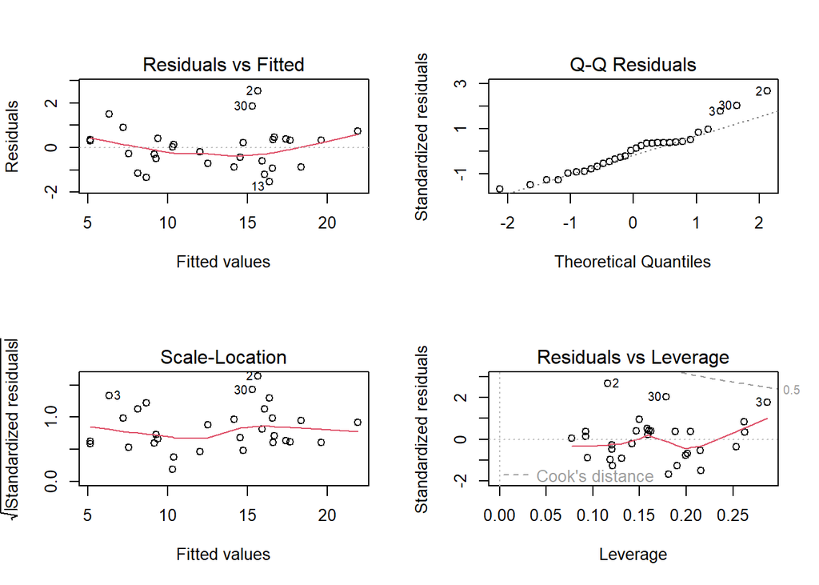

```r
par(mfrow = c(2, 2))
plot(model)
```

```r
# Hiển thị kết quả mô hình
summary(model)
```

```
##
## Call:
## lm(formula = y ~ x1 + x2 + x3 + x4, data = transformed_data)
##
## Residuals:
##      Min       1Q   Median       3Q      Max
## -1.52768 -0.67257  0.08572  0.36968  2.53066
##
## Coefficients:
##             Estimate Std. Error t value Pr(>|t|)
## (Intercept)  0.35745    0.67341   0.531   0.6002
## x1           0.44486    0.05468   8.136 1.72e-08 ***
## x2          -0.18087    0.06668  -2.713   0.0119 *
## x3           1.50509    0.06161  24.428  < 2e-16 ***
## x4           0.03193    0.03657   0.873   0.3910
## ---
## Signif. codes:  0 '***' 0.001 '**' 0.01 '*' 0.05 '.' 0.1 ' ' 1
##
## Residual standard error: 1.005 on 25 degrees of freedom
## Multiple R-squared:  0.9603, Adjusted R-squared:  0.9539
## F-statistic: 151.1 on 4 and 25 DF,  p-value: < 2.2e-16
```

$H_0$: $\beta_i$ = 0 với mọi i

$H_1$: Tồn tại $\beta_i$ != 0

Kết luận: Bác bỏ $H_0$ vì p-value nhỏ => Vậy tồn tại $\beta_i$ != 0

## 2.4. Phương pháp tiếp cận tổng quát cho quy trình biến đổi biến

```r
library(car)
library(alr3)
library(extras)
```

Quy trình biến đổi biến đòi hỏi một cách tiếp cận “thử và sai”. Khi xây dựng một mô hình hồi quy tuyến tính, ta thử một phép biến đổi và sau đó phải kiểm tra xem liệu phép biến đổi đó có loại bỏ được các vấn đề với mô hình hay chưa. Nếu nó không giúp ích được gì, ta lại thử một phép biến đổi khác. Và ta sẽ tiếp tục lặp lại quá trình này cho đến khi xây dựng được một mô hình thỏa hết các giả định của hồi quy tuyến tính. Lúc đó ta mới có thể sử dụng mô hình này để suy luận và dự đoán [1].

Nhu cầu sử dụng các phép biến đổi biến phát sinh do các biến ban đầu, hoặc mô hình theo các biến ban đầu, vi phạm một hoặc nhiều giả định của hồi quy tuyến tính. Trong đó, biến đổi biến thường được dùng để xử lý khi một trong ba giả định sau bị vi phạm [1]:

- Tính tuyến tính: Giữa biến phụ thuộc Y và các biến độc lập X<sub>1</sub> , …, X<sub>k</sub> phải có mối quan hệ tuyến tính.
- Tính chuẩn: Các sai số phải tuân theo phân phối chuẩn.
- Tính ổn định phương sai: Các sai số phải có phương sai không đổi.

Xét một mô hình hồi quy tuyến tính:

Y<sub>i</sub> = $\beta_{0}$ + $\beta_{1}$x<sub>i1</sub> + $\beta_{2}$x<sub>i2</sub> + … + $\beta_{k}$x<sub>ik</sub>+ $\epsilon_{i}$ với i = 1, …, n (n là số quan trắc)

Ta có các trường hợp như sau:

1. **Trường hợp 1:** Nếu nhận thấy chỉ có giả định về tính tuyến tính không được thỏa thì ta có thể bắt đầu bằng việc thử biến đổi các biến X<sub>1</sub> , …, X<sub>k</sub> [1].

   Ví dụ 1:

   ```r
   # Dataset wordrecall (2 biến, 13 quan trắc): Nghiên cứu mà trong đó 13 người được yêu cầu ghi nhớ một danh sách các từ (prop: tỷ lệ các từ được nhớ đúng; time: thời gian (phút) kể từ khi danh sách các từ được ghi nhớ)
   wordrecall <- read.table("wordrecall.txt", header = TRUE)
   wordrecall
   ```

   ```
   ##     time prop
   ## 1      1 0.84
   ## 2      5 0.71
   ## 3     15 0.61
   ## 4     30 0.56
   ## 5     60 0.54
   ## 6    120 0.47
   ## 7    240 0.45
   ## 8    480 0.38
   ## 9    720 0.36
   ## 10  1440 0.26
   ## 11  2880 0.20
   ## 12  5760 0.16
   ## 13 10080 0.08
   ```

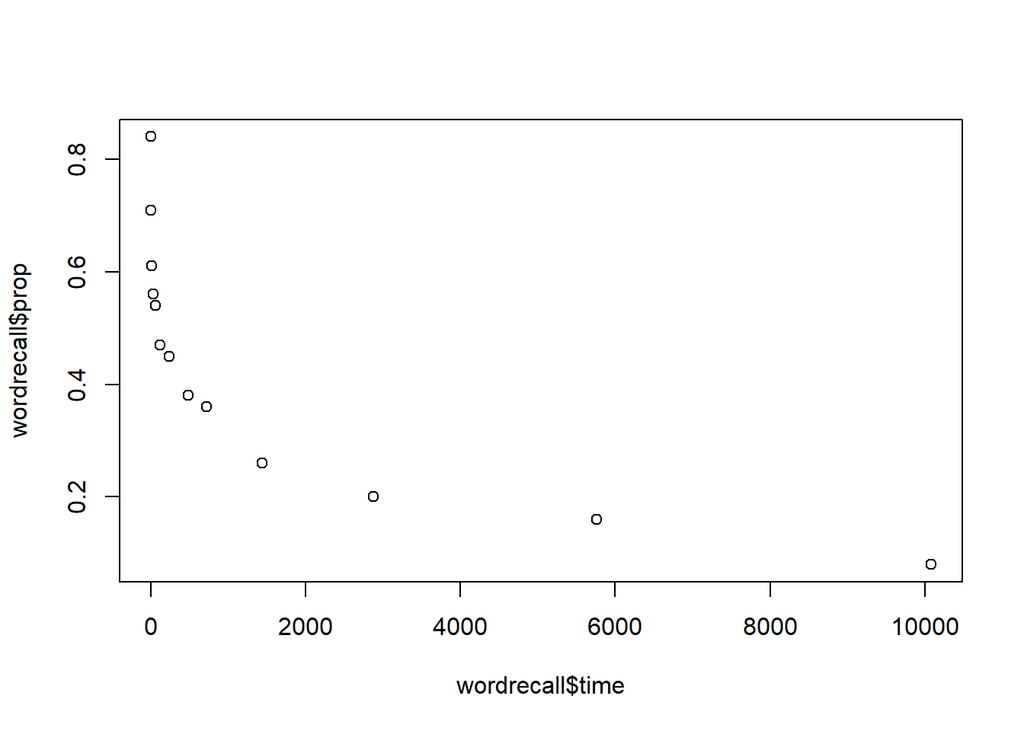

   Từ đồ thị vẽ biến prop theo biến time, ta thấy giữa hai biến không có mối quan hệ tuyến tính.

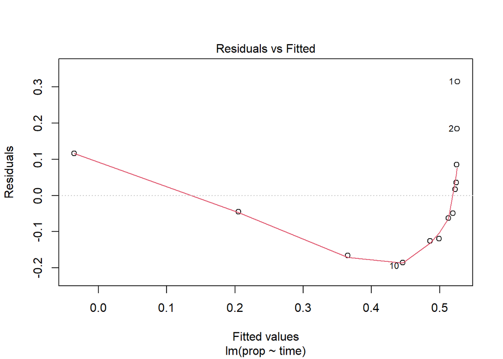

   ```r
   plot(mod,1)
   ```

   Từ biểu đồ vẽ giá trị thặng dư theo giá trị ước lượng, có thể thấy đường màu đỏ không nằm ngang ở gần đường y = 0, và các điểm trên biểu đồ không phân bố đều xung quanh đường màu đỏ. Do đó, có vẻ như mô hình đang không thỏa giả định về kỳ vọng của sai số luôn bằng 0 và giả định về tính tuyến tính.

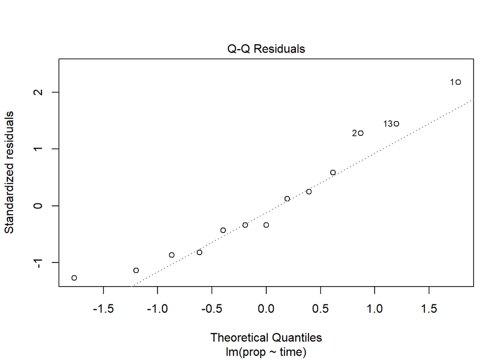

   ```r
   plot(mod,2)
   ```

   Từ biểu đồ Q - Q plot của các giá trị thặng dư, ta thấy các điểm trên biểu đồ nằm khá sát đường thẳng, nên có vẻ như mô hình thỏa giả định về tính chuẩn.

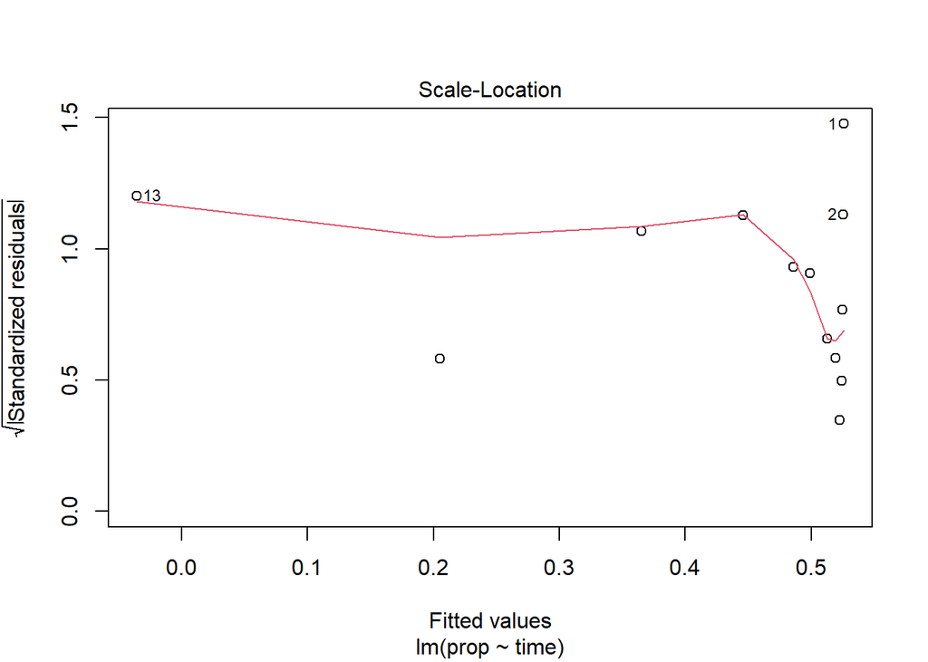

   ```r
   plot(mod,3)
   ```

   Từ biểu đồ vẽ căn bậc hai của giá trị thặng dư theo giá trị ước lượng, có thể thấy đường màu đỏ không nằm ngang mà bị cong xuống ở phần đuôi, và các điểm trên biểu đồ không phân bố đều xung quanh đường màu đỏ. Tuy nhiên, điều này có thể đã bị ảnh hưởng bởi việc giả định về tính tuyến tính ban nãy không thỏa. Do đó, ta chưa kết luận được gì về tính ổn định phương sai từ biểu đồ này.

   Nay ta đi kiểm tra lại giả định về tính chuẩn và tính ổn định phương sai bằng các kiểm định:

   ```r
   shapiro.test(resid(mod))
   ```

   ```
   ##
   ##  Shapiro-Wilk normality test
   ##
   ## data:  resid(mod)
   ## W = 0.94755, p-value = 0.5616
   ```

   Kiểm định Shapiro - Wilk có:

   H<sub>0</sub> : Các sai số cùng tuân theo phân phối chuẩn.

   H<sub>1</sub> : Các sai số không cùng tuân theo phân phối chuẩn.

   Ở đây, vì p - value = 0.5616 > 0.05 nên ta không đủ cơ sở để bác bỏ H<sub>0</sub> với mức ý nghĩa 0.05. Và ta kết luận rằng mô hình thỏa giả định về tính chuẩn.

   ```r
   ncvTest(mod)
   ```

   ```
   ## Non-constant Variance Score Test
   ## Variance formula: ~ fitted.values
   ## Chisquare = 0.2115065, Df = 1, p = 0.64559
   ```

   Kiểm định ncvTest có:

   H<sub>0</sub> : Các sai số có phương sai không đổi.

   H<sub>1</sub> : Các sai số có phương sai thay đổi.

   Ở đây, vì p - value = 0.6456 > 0.05 nên ta không đủ cơ sở để bác bỏ H<sub>0</sub> với mức ý nghĩa 0.05. Và ta kết luận rằng mô hình thỏa giả định về tính ổn định phương sai.

   Tóm lại, mô hình của chúng ta chỉ không thỏa giả định về tính tuyến tính, do đó ta có thể thử biến đổi biến độc lập time.

   --------------------------------------------------------------------------------------------------------------

   Phép biến đổi phù hợp cho một biến X<sub>j</sub> có thể được tìm bằng cách sử dụng phương pháp Box - Cox / Yeo - Johnson. Để tìm phép biến đổi phù hợp cho nhiều biến độc lập hoàn toàn dương cùng một lúc, ta có thể sử dụng phương pháp Box - Cox đa biến [2].
2. **Trường hợp 2:** Nếu nhận thấy chỉ có giả định về tính chuẩn và / hoặc giả định về tính ổn định phương sai không được thỏa thì ta có thể thử biến đổi biến Y [1].

   Ví dụ 2:

   ```r
   # Dataset cars (2 biến, 50 quan trắc): Nghiên cứu mối quan hệ giữa tốc độ của xe và khoảng cách đến khi xe dừng lại (dist: khoảng cách đến khi xe dừng lại; speed: tốc độ của xe)
   cars
   ```

   ```
   ##    speed dist
   ## 1      4    2
   ## 2      4   10
   ## 3      7    4
   ## 4      7   22
   ## 5      8   16
   ## 6      9   10
   ## 7     10   18
   ## 8     10   26
   ## 9     10   34
   ## 10    11   17
   ## 11    11   28
   ## 12    12   14
   ## 13    12   20
   ## 14    12   24
   ```

   [output cut: 36 more lines]

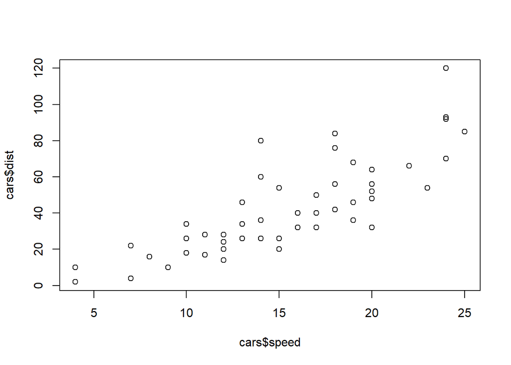

   ```r
   # Mô hình hồi quy tuyến tính đơn với dist là biến phụ thuộc và speed là biến độc lập:
   mod2 <- lm(dist ~ speed, data = cars)

   plot(cars$speed, cars$dist)
   ```

   Từ đồ thị vẽ biến dist theo biến speed, ta thấy có vẻ như giữa hai biến có mối quan hệ tuyến tính.

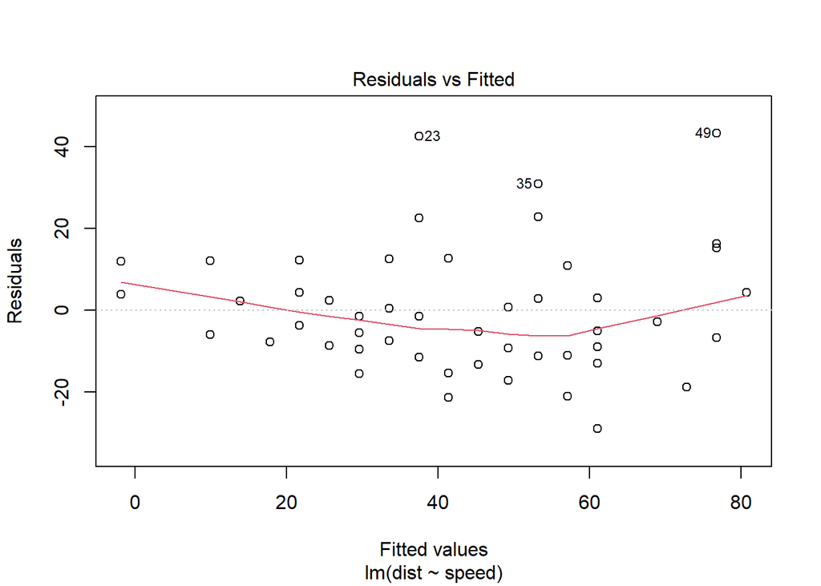

   ```r
   plot(mod2, 1)
   ```

   Từ biểu đồ vẽ giá trị thặng dư theo giá trị ước lượng, có thể thấy đường màu đỏ nằm tương đối ngang ở gần đường y = 0, và các điểm trên biểu đồ phân bố khá đều xung quanh đường màu đỏ. Do đó, có vẻ như mô hình thỏa giả định về kỳ vọng của sai số luôn bằng 0 và giả định về tính tuyến tính.

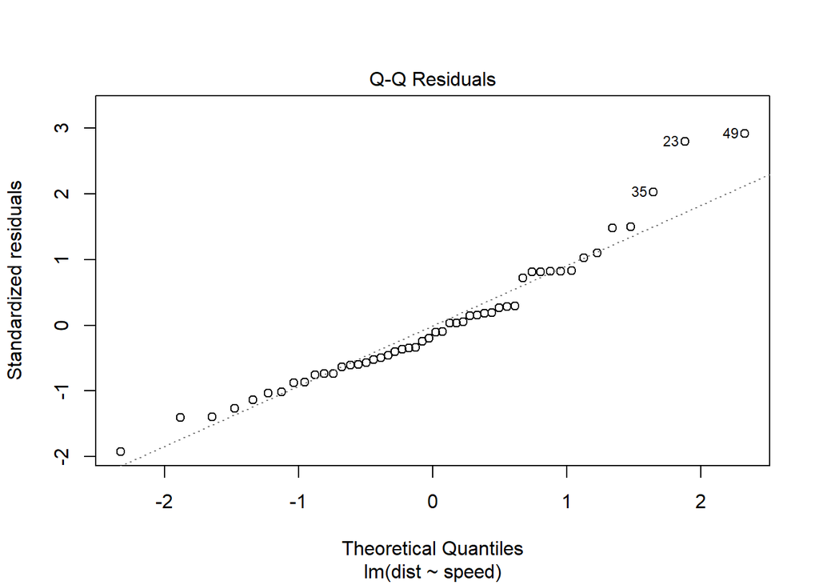

   ```r
   plot(mod2, 2)
   ```

   Từ biểu đồ Q - Q plot của các giá trị thặng dư, ta thấy đa số các điểm trên biểu đồ nằm khá sát đường thẳng. Tuy nhiên có một số điểm (ví dụ như điểm tương ứng với quan trắc thứ 23 và 49) nằm hơi xa đường thẳng. Do đó, ta chưa kết luận được gì về tính chuẩn từ biểu đồ này.

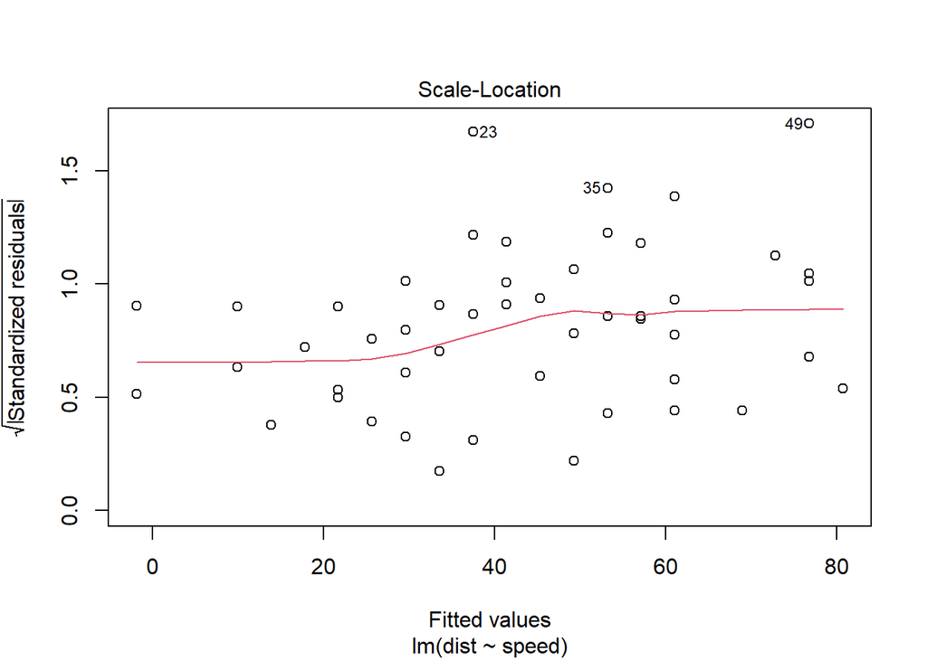

   ```r
   plot(mod2, 3)
   ```

   Từ biểu đồ vẽ căn bậc hai của giá trị thặng dư theo giá trị ước lượng, có thể thấy đường màu đỏ nằm tương đối thẳng, và các điểm trên biểu đồ phân bố khá đều xung quanh đường màu đỏ. Tuy nhiên có một số điểm (ví dụ như điểm tương ứng với quan trắc thứ 23 và 49) nằm hơi xa đường màu đỏ. Do đó, ta cũng chưa kết luận được gì về tính ổn định phương sai từ biểu đồ này.

   Nay ta đi kiểm tra lại giả định về tính chuẩn và tính ổn định phương sai bằng các kiểm định:

   ```r
   shapiro.test(resid(mod2))
   ```

   ```
   ##
   ##  Shapiro-Wilk normality test
   ##
   ## data:  resid(mod2)
   ## W = 0.94509, p-value = 0.02152
   ```

   Kiểm định Shapiro - Wilk có:

   H<sub>0</sub> : Các sai số cùng tuân theo phân phối chuẩn.

   H<sub>1</sub> : Các sai số không cùng tuân theo phân phối chuẩn.

   Ở đây, vì p - value = 0.0215 < 0.05 nên ta bác bỏ H<sub>0</sub> với mức ý nghĩa 0.05. Và ta kết luận rằng mô hình không thỏa giả định về tính chuẩn.

   ```r
   ncvTest(mod2)
   ```

   ```
   ## Non-constant Variance Score Test
   ## Variance formula: ~ fitted.values
   ## Chisquare = 4.650233, Df = 1, p = 0.031049
   ```

   Kiểm định ncvTest có:

   H<sub>0</sub> : Các sai số có phương sai không đổi.

   H<sub>1</sub> : Các sai số có phương sai thay đổi.

   Ở đây, vì p - value = 0.0310 < 0.05 nên ta bác bỏ H<sub>0</sub> với mức ý nghĩa 0.05. Và ta kết luận rằng mô hình không thỏa giả định về tính ổn định phương sai.

   Như vậy, mô hình của chúng ta đang không thỏa giả định về tính chuẩn và tính ổn định phương sai, do đó ta có thể thử biến đổi biến phụ thuộc dist.

   ----------------------------------------------------------------------------------------------------------------

   Phép biến đổi phù hợp cho Y có thể được tìm bằng phương pháp Box - Cox / Yeo - Johnson.

   Đặc biệt, trong trường hợp biến X tuân theo phân phối chuẩn (đối với hồi quy tuyến tính đơn) hoặc các đồ thị phân tán thể hiện sự tương quan giữa từng cặp biến độc lập đều có dạng gần với hàm tuyến tính (đối với hồi quy tuyến tính bội) thì ta có thể sử dụng biểu đồ inverse response plot để tìm phép biến đổi phù hợp cho Y.

   Ví dụ 2 (tiếp tục):

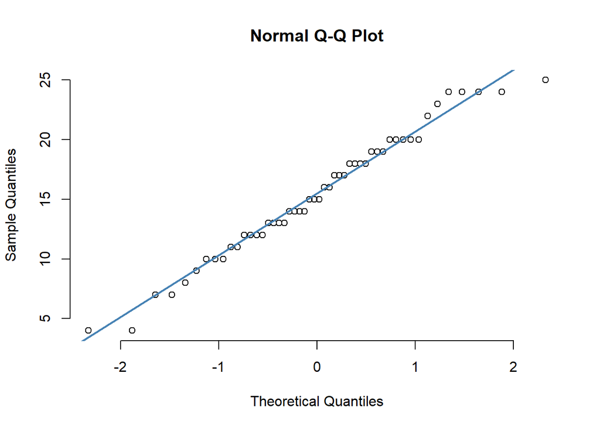

   ```r
   qqnorm(cars$speed, pch = 1, frame = FALSE)
   qqline(cars$speed, col = "steelblue", lwd = 2)
   ```

   ```r
   shapiro.test(cars$speed)
   ```

   ```
   ##
   ##  Shapiro-Wilk normality test
   ##
   ## data:  cars$speed
   ## W = 0.97765, p-value = 0.4576
   ```

   Ta xét thử Q - Q plot của biến độc lập speed thì thấy biến này có vẻ tuân theo phân phối chuẩn, và khi kiểm tra lại bằng kiểm định Shapiro - Wilk thì thấy p - value = 0.4576 > 0.05 nên ta không đủ cơ sở để bác bỏ H<sub>0</sub> : *Biến speed tuân theo phân phối chuẩn* với mức ý nghĩa 0.05. Vì vậy, ta kết luận rằng biến speed tuân theo phân phối chuẩn.

   Khi đó, ta vẽ được biểu đồ inverse response plot, là biểu đồ vẽ giá trị ước lượng $\widehat{dist}$ theo dist ứng với từng giá trị $\lambda \in \{\hat{\lambda} , -1, 0, 1\}$. Trong đó, $\hat{\lambda}$ là giá trị $\lambda$ tối ưu cho hàm biến đổi lũy thừa trên biến dist, là giá trị $\lambda$ làm cực tiểu hàm tổng bình phương phần dư RSS.

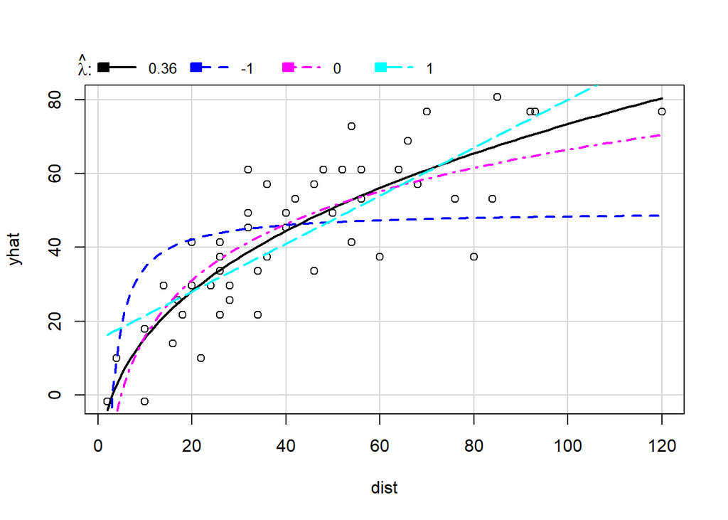

   ```
   ##       lambda       RSS
   ## 1  0.3625675  6069.639
   ## 2 -1.0000000 14618.810
   ## 3  0.0000000  6857.167
   ## 4  1.0000000  7392.043
   ```

   ```r
   invResPlot(mod2)
   ```

   Ở đây, $\hat{\lambda}$ = 0.36 thì ta có thể làm tròn thành 0.33, ứng với phép biến đổi lấy căn bậc ba.

   --------------------------------------------------------------------------------------------------------------

   Trong biểu đồ inverse response plot, nếu đường cong ứng với $\lambda = \hat{\lambda}$ thể hiện xu hướng phi tuyến rõ ràng thì ta nên biến đổi Y theo $\hat{\lambda}$ trong đồ thị, còn nếu đường cong đó không thể hiện xu hướng phi tuyến rõ ràng thì mọi phép biến đổi trên biến Y sẽ nhiều khả năng đều không có ích [2].

   Lưu ý rằng, mặc dù ban đầu một số giả định có thể thỏa cho mô hình, nhưng sau khi áp dụng biến đổi biến thì chúng có thể không còn thỏa nữa. Do đó, ta cần kiểm tra lại tất cả các giả định hồi quy tuyến tính sau mỗi lần thực hiện phép biến đổi biến [1].
3. **Trường hợp 3:** Nếu như cả giả định về tính tuyến tính, tính chuẩn và tính ổn định phương sai đều bị vi phạm thì ta có thể cần biến đổi cả các biến X<sub>1</sub> , …, X<sub>k</sub> lẫn biến Y.

   Ví dụ 3:

   ```r
   # Dataset BigMac2003 (10 biến, 69 quan trắc): Nghiên cứu ảnh hưởng của nhiều yếu tố đến khả năng mua hamburger BigMac (BigMac: Số phút lao động để có được đủ tiền mua một hamburger BigMac, Bread: Số phút lao động để có được đủ tiền mua 1kg bánh mì, Rice: Số phút làm việc để có được đủ tiền mua 1kg gạo, FoodIndex: Chỉ số giá thực phẩm, ...)
   BigMac2003
   ```

   ```
   ##                   BigMac Bread Rice FoodIndex  Bus  Apt TeachGI TeachNI
   ## Amsterdam             16     9    9      65.9 2.00  890    34.3    20.5
   ## Athens                21    12   19      63.5 0.61  620    19.5    15.9
   ## Auckland              19    19    9      55.4 1.57  780    22.0    16.1
   ## Bangkok               50    42   25      46.4 0.47  120     4.2     4.0
   ## Barcelona             22    19   10      62.9 0.91  590    25.5    20.1
   ## Basel                 15     7    7      98.4 2.34  930    78.5    57.6
   ## Berlin                16    10   16      64.4 2.21  630    45.0    28.9
   ## Bogota                93    48   16      33.3 0.32  200     4.1     3.9
   ## Bratislava            54    20   28      36.9 0.36  350     4.1     3.3
   ## Brussels              18    11   12      74.7 1.50  590    30.6    18.9
   ## Bucharest             79    22   21      36.4 0.20  150     1.8     1.6
   ## Budapest              43    14   22      43.9 0.53  440     6.2     4.3
   ## Buenos_Aries          45    28   36      27.3 0.25  150     2.4     2.0
   ## Caracas               76    89   17      49.5 0.20  290     3.5     3.1
   ## Chicago               10     7    7      93.2 1.50 1430    47.2    35.5
   ## Copenhagen            16    10    5      78.0 2.17  940    42.5    24.5
   ## Dubai                 22    15   16      63.6 0.68 1350    22.8    22.8
   ## Dublin                15     8   14      74.7 1.39 1320    41.7    30.8
   ## Frankfurt             15     6   16      62.3 3.43  920    41.9    30.5
   ## Geneva                16     7    7     100.6 1.46 1630    76.4    54.8
   ## Helsinki              19    22   12      75.3 2.15  560    30.5    21.7
   ## Hong_Kong             13    27   13     128.2 1.26 1750    47.1    40.4
   ## Istanbul              36    19   34      51.0 0.61  890    10.4     8.3
   ## Jakarta               67    25   20      49.9 0.27 1110     2.3     2.1
   ## Johannesburg          33    11   14      41.1 0.70  480     7.5     5.8
   ## Karachi              132    62   46      35.7 0.22   90     2.0     1.8
   ## Kiev                  84    13   28      25.7 0.09  310     0.6     0.5
   ## Kuala_Lumpur          25    20   10      41.4 0.53  460    10.2     8.5
   ## Lagos                 55    60   71      74.1 0.15  100     1.7     1.5
   ## Lima                  79    38   21      41.0 0.34  300     4.1     4.4
   ## Lisbon                33    18   11      58.7 1.82  810    16.0    11.8
   ## Ljubljana             39    39   24      57.3 0.79  170    17.8    10.7
   ## London                16     6   14      69.3 2.08 1930    33.7    24.2
   ## Los_Angeles           10    16    8      89.2 1.10 1060    46.7    36.2
   ## Lugano                17     7    5      94.9 1.83  950    59.5    45.2
   ## Luxembourg            15    14   14      72.2 1.29  700    58.0    45.9
   ## Madrid                21    15   12      62.2 1.18  740    27.6    21.8
   ## Manama                24    26   19      76.5 0.13  800    13.3    12.6
   ## Manila                62    49   26      63.9 1.46  650     4.0     3.4
   ```

   [output cut: 85 more lines]

   ```
   ## Sao_Paulo         11.11110         21
   ## Seoul             20.22060         58
   ## Shanghi           23.25580         40
   ## Singapore         21.73910         45
   ## Sofia             19.04760         40
   ## Stockholm         35.60370         40
   ## Sydney            28.80660         38
   ## Taipei            17.48880         40
   ## Tallinn           29.41180         25
   ## Tel_Aviv          17.16420         30
   ## Tokyo             16.37550         49
   ## Toronto           30.18870         49
   ## Vienna            31.48790         37
   ## Vilnius           29.72970         32
   ## Warsaw            35.84910         26
   ```

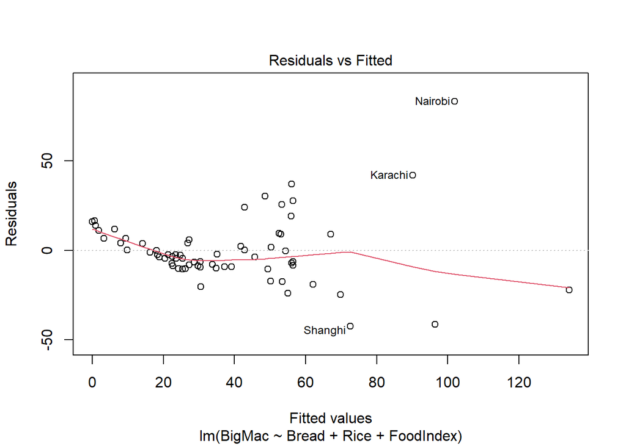

   ```r
   # Mô hình hồi quy tuyến tính bội với BigMac là biến phụ thuộc và Bread, Rice, FoodIndex là các biến độc lập:
   mod3 <- lm(BigMac ~ Bread + Rice + FoodIndex, data = BigMac2003)

   plot(mod3, 1)
   ```

   Từ biểu đồ vẽ giá trị thặng dư theo giá trị ước lượng, có thể thấy đường màu đỏ nằm tương đối ngang ở gần đường y = 0, tuy nhiên các điểm trên biểu đồ không phân bố đều xung quanh đường màu đỏ. Do đó, có vẻ như mô hình thỏa giả định về kỳ vọng của sai số luôn bằng 0, nhưng không thỏa giả định về tính tuyến tính.

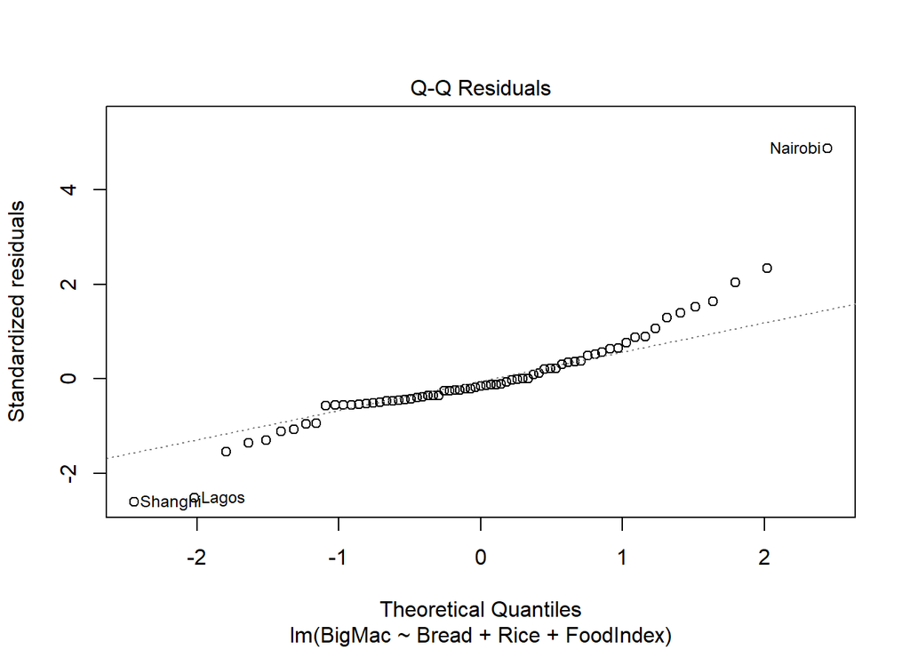

   ```r
   plot(mod3, 2)
   ```

   Từ biểu đồ Q - Q plot của các giá trị thặng dư, ta thấy các điểm ở giữa biểu đồ nằm khá sát đường thẳng. Tuy nhiên có một số điểm ở bên trái và bên phải của biểu đồ (ví dụ như điểm tương ứng với quan trắc của vùng Nairobi và vùng Shangni) nằm hơi xa đường thẳng. Do đó, ta chưa kết luận được gì về tính chuẩn từ biểu đồ này.

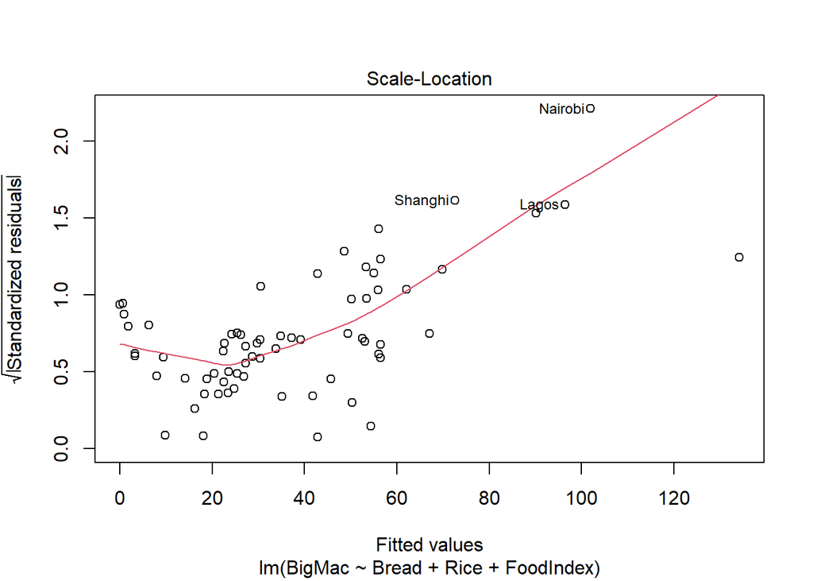

   ```r
   plot(mod3, 3)
   ```

   Từ biểu đồ vẽ căn bậc hai của giá trị thặng dư theo giá trị ước lượng, có thể thấy đường màu đỏ hoàn toàn không nằm ngang, và các điểm trên biểu đồ không phân bố đều xung quanh đường màu đỏ. Tuy nhiên, điều này có thể đã bị ảnh hưởng bởi việc giả định về tính tuyến tính ban nãy không thỏa. Do đó, ta cũng chưa kết luận được gì về tính ổn định phương sai từ biểu đồ này.

   Nay ta đi kiểm tra lại giả định về tính chuẩn và tính ổn định phương sai bằng các kiểm định:

   ```r
   shapiro.test(resid(mod3))
   ```

   ```
   ##
   ##  Shapiro-Wilk normality test
   ##
   ## data:  resid(mod3)
   ## W = 0.88787, p-value = 1.509e-05
   ```

   Kiểm định Shapiro - Wilk có:

   H<sub>0</sub> : Các sai số cùng tuân theo phân phối chuẩn.

   H<sub>1</sub> : Các sai số không cùng tuân theo phân phối chuẩn.

   Ở đây, vì p - value = 1.509 x 10<sup>-5</sup> < 0.05 nên ta bác bỏ H<sub>0</sub> với mức ý nghĩa 0.05. Và ta kết luận rằng mô hình không thỏa giả định về tính chuẩn.

   ```r
   ncvTest(mod3)
   ```

   ```
   ## Non-constant Variance Score Test
   ## Variance formula: ~ fitted.values
   ## Chisquare = 70.16487, Df = 1, p = < 2.22e-16
   ```

   Kiểm định ncvTest có:

   H<sub>0</sub> : Các sai số có phương sai không đổi.

   H<sub>1</sub> : Các sai số có phương sai thay đổi.

   Ở đây, vì p - value < 2.22 x 10<sup>-16</sup> < 0.05 nên ta bác bỏ H<sub>0</sub> với mức ý nghĩa 0.05. Và ta kết luận rằng mô hình không thỏa giả định về tính ổn định phương sai.

   Tóm lại, mô hình của chúng ta đang không thỏa cả ba giả định về tính tuyến tính, tính chuẩn và tính ổn định phương sai, do đó ta có thể thử biến đổi cả các biến độc lập Bread, Rice, FoodIndex lẫn biến phụ thuộc BigMac.

   ----------------------------------------------------------------------------------------------------------------

   Việc biến đổi X<sub>1</sub> , …, X<sub>k</sub> sẽ chủ yếu khắc phục vấn đề liên quan đến tính tuyến tính, còn việc biến đổi Y sẽ khắc phục được các vấn đề về sai số (và cũng có thể giúp ích cho vấn đề về tính tuyến tính) [1]. Lúc này, ta có hai cách để tiếp cận việc biến đổi biến [3]:
   - *Cách 1:* Ta sử dụng phương pháp Box - Cox đa biến để tìm phép biến đổi phù hợp cho các biến X<sub>1</sub> , …, X<sub>k</sub> , nếu các biến này hoàn toàn dương, nhằm đưa các biến này gần về phân phối chuẩn đồng thời. Sau đó, sử dụng đồ thị inverse response plot để tìm phép biến đổi phù hợp cho Y.
   - *Cách 2:* Ta có thể sử dụng phương pháp Box - Cox đa biến để tìm phép biến đổi phù hợp cho cả biến Y lẫn các biến X<sub>1</sub> , …, X<sub>k</sub> cùng một lúc, nếu như tất cả các biến này đều hoàn toàn dương.

Ngoài ra, nếu trong mô hình có biến giả (dummy variable) thì ta không nên biến đổi các biến này [2]. Vì biến giả là biến lấy giá trị nhị phân (0 hoặc 1) để thể hiện sự tồn tại hoặc không tồn tại của một yếu tố phân loại nào đó, nên việc biến đổi các biến này bằng các phép toán có thể làm mất tính giải thích được của chúng.

Sau khi đã xây dựng được một mô hình thỏa đủ các giả định của hồi quy tuyến tính, ta mới có thể dùng mô hình này để suy luận và dự báo.

# 3. Demo

## Import package

```r
library("readxl")
library(data.table)
library(corrplot)
library(car)
library(psych)
```

## Load dataset

Data thu thập trên 48 tiểu bang của Hoa kỳ với các biến :

TAX: thuế trên xăng dầu (100/galong)

DLIC: % người có bằng lái

INC: thu nhập trên đầu người (nghìn đô la)

ROAD: nghìn dặm đường cao tốc

Y: mức tiêu thụ xăng trên đầu người

```r
data <- read_excel("lươngtieuthuxang.XLS")
setnames(data, "Tiểu bang HK", "HK")
setnames(data, "TAX x_i1", "TAX_x_i1")
setnames(data, "DLIC x_i2", "DLIC_x_i2")
setnames(data, "INC x_i13", "INC_x_i13")
setnames(data, "ROAD x_i4", "ROAD_x_i4")
setnames(data, "FUEL x_i5", "FUEL_x_i5")
dim(data)
```

```
## [1] 48  6
```

```r
head(data)
```

```
## # A tibble: 6 × 6
##   HK    TAX_x_i1 DLIC_x_i2 INC_x_i13 ROAD_x_i4 FUEL_x_i5
##   <chr>    <dbl>     <dbl>     <dbl>     <dbl>     <dbl>
## 1 ME         9        52.5      3.57     1.98        541
## 2 NH         9        57.2      4.09     1.25        524
## 3 VT         9        58        3.86     1.59        561
## 4 MA         7.5      52.9      4.87     2.35        414
## 5 RI         8        54.4      4.40     0.431       410
## 6 CN        10        57.1      5.34     1.33        457
```

```r
data <- data[,-1]
head(data)
```

```
## # A tibble: 6 × 5
##   TAX_x_i1 DLIC_x_i2 INC_x_i13 ROAD_x_i4 FUEL_x_i5
##      <dbl>     <dbl>     <dbl>     <dbl>     <dbl>
## 1      9        52.5      3.57     1.98        541
## 2      9        57.2      4.09     1.25        524
## 3      9        58        3.86     1.59        561
## 4      7.5      52.9      4.87     2.35        414
## 5      8        54.4      4.40     0.431       410
## 6     10        57.1      5.34     1.33        457
```

## Phân tích tương quan

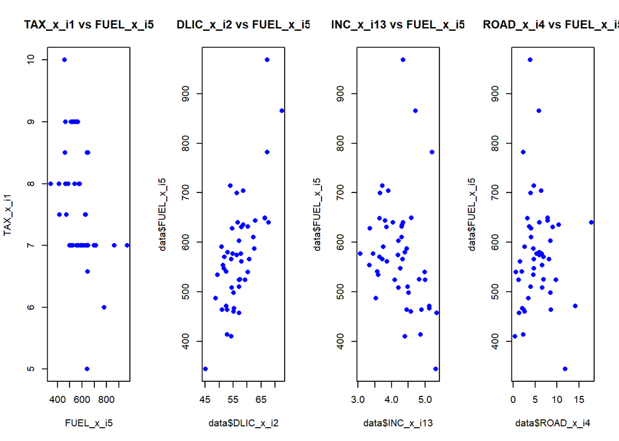

```r
op <- par(mfrow = c(1,4))
plot(TAX_x_i1 ~ FUEL_x_i5, data = data, pch = 16, col = 'blue',main = "TAX_x_i1 vs FUEL_x_i5")
plot(data$DLIC_x_i2, data$FUEL_x_i5, pch = 16, col = 'blue', main = "DLIC_x_i2 vs FUEL_x_i5")
plot(data$INC_x_i13, data$FUEL_x_i5, pch = 16, col = 'blue', main = "INC_x_i13 vs FUEL_x_i5")
plot(data$ROAD_x_i4, data$FUEL_x_i5, pch = 16, col = 'blue', main = "ROAD_x_i4 vs FUEL_x_i5")
```

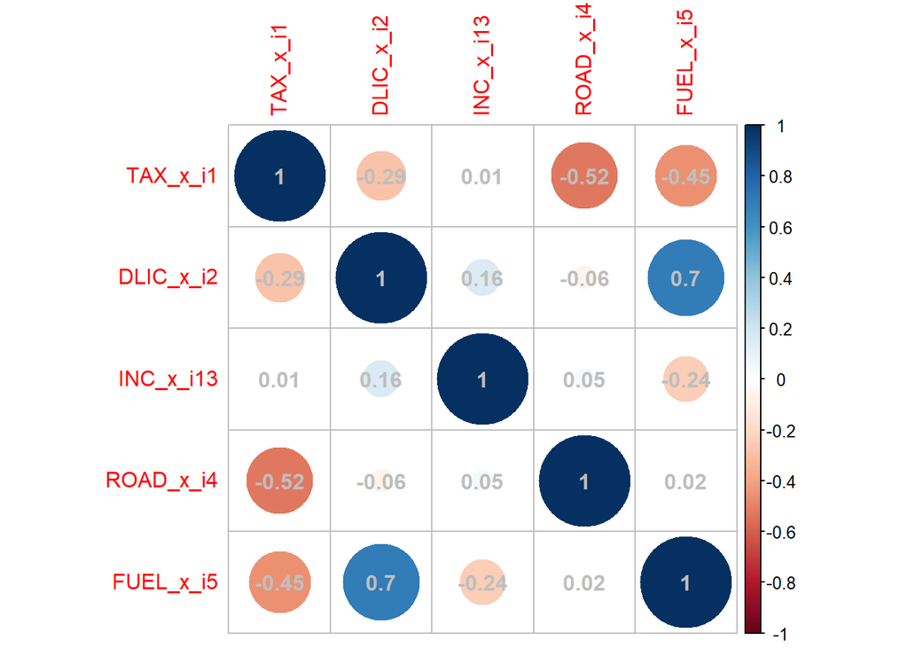

```r
corrplot(cor(data), method = "circle", addCoef.col = "grey")
```

## Fit model

```r
mod <- lm(FUEL_x_i5 ~ ., data = data)
summary(mod)
```

```
##
## Call:
## lm(formula = FUEL_x_i5 ~ ., data = data)
##
## Residuals:
##     Min      1Q  Median      3Q     Max
## -122.01  -45.58  -10.67   31.53  234.95
##
## Coefficients:
##             Estimate Std. Error t value Pr(>|t|)
## (Intercept)  377.198    185.539   2.033 0.048257 *
## TAX_x_i1     -34.782     12.969  -2.682 0.010343 *
## DLIC_x_i2     13.365      1.923   6.950 1.52e-08 ***
## INC_x_i13    -66.593     17.222  -3.867 0.000368 ***
## ROAD_x_i4     -2.423      3.389  -0.715 0.478548
## ---
## Signif. codes:  0 '***' 0.001 '**' 0.01 '*' 0.05 '.' 0.1 ' ' 1
##
## Residual standard error: 66.31 on 43 degrees of freedom
## Multiple R-squared:  0.6787, Adjusted R-squared:  0.6488
## F-statistic: 22.71 on 4 and 43 DF,  p-value: 3.91e-10
```

$H_0$: $\beta_i$ = 0 với mọi i

$H_1$: $\beta_i$ != 0

p-value của ROAD_x_i4 lớn hơn 0.05 => chấp nhận $H_0$ => $\beta_4$ =0

=> ROAD_x_i4 không ảnh hưởng đến lượng xăng FUEL_x_i5.

Ta sẽ tạo mô hình thứ hai để loại bỏ ROAD_x_i4

```r
mod2 <- lm(FUEL_x_i5 ~ TAX_x_i1 + DLIC_x_i2 + INC_x_i13, data = data)
summary(mod2)
```

```
##
## Call:
## lm(formula = FUEL_x_i5 ~ TAX_x_i1 + DLIC_x_i2 + INC_x_i13, data = data)
##
## Residuals:
##     Min      1Q  Median      3Q     Max
## -110.10  -51.22  -12.89   24.49  238.77
##
## Coefficients:
##             Estimate Std. Error t value Pr(>|t|)
## (Intercept)  307.328    156.831   1.960  0.05639 .
## TAX_x_i1     -29.484     10.584  -2.786  0.00785 **
## DLIC_x_i2     13.748      1.837   7.485 2.24e-09 ***
## INC_x_i13    -68.023     17.010  -3.999  0.00024 ***
## ---
## Signif. codes:  0 '***' 0.001 '**' 0.01 '*' 0.05 '.' 0.1 ' ' 1
##
## Residual standard error: 65.94 on 44 degrees of freedom
## Multiple R-squared:  0.6749, Adjusted R-squared:  0.6527
## F-statistic: 30.44 on 3 and 44 DF,  p-value: 8.235e-11
```

### kiểm tra đa cộng tuyến

```r
vif(mod2)
```

```
##  TAX_x_i1 DLIC_x_i2 INC_x_i13
##  1.094575  1.122082  1.029153
```

Đảm bảo không có đa cộng tuyến

### Giả định của mô hình

##đồ thị phần dư

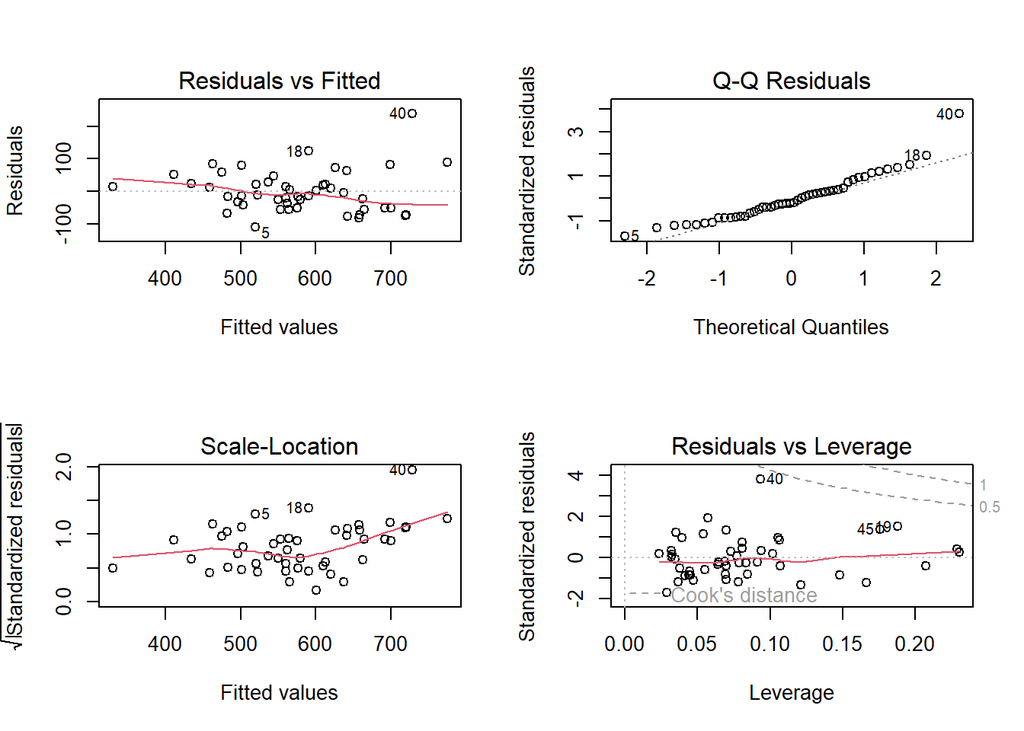

```r
par(mfrow = c(2, 2))
plot(mod2)
```

Đồ thị thứ nhất: Các điểm giá trị thặng dư phân tán xung quanh đường màu đỏ, tuy nhiên có một vài điểm ở xa => có thể không có tính tuyến tính giữa biến phụ thuộc và các biến độc lập

Đồ thị thứ 2: Các điểm giá trị thặng dư gần như nằm trên đường thẳng => có thể thoả mãn tính chuẩn

Đồ thị thứ 3: Đường màu đỏ ko thẳng lắm , có một vài điểm ở xa => chưa kết luận được tính ổn định của phương sai

# Kiểm định

### Tính chuẩn

$H_0$: $\epsilon_i$ có phân phối chuẩn

$H_1$: $\epsilon_i$ không có phân phối chuẩn

```r
shapiro.test(resid(mod2))
```

```
##
##  Shapiro-Wilk normality test
##
## data:  resid(mod2)
## W = 0.9282, p-value = 0.005858
```

p-value nhỏ => bác bỏ $H_0$ => không thoả mãn tính chuẩn

### Trung bình sai số = 0

$H_0$: $E(\epsilon_i)$ = 0

$H_1$: $E(\epsilon_i)$ != 0

```r
t.test(resid(mod2), mu = 0)
```

```
##
##  One Sample t-test
##
## data:  resid(mod2)
## t = -2.6826e-16, df = 47, p-value = 1
## alternative hypothesis: true mean is not equal to 0
## 95 percent confidence interval:
##  -18.52519  18.52519
## sample estimates:
##     mean of x
## -2.470246e-15
```

p-value = 1 => không bác bỏ $H_0$ => thoả mãn $E(\epsilon_i)$ =0

### Tính ổn định của phương sai

$H_0$: phương sai không đổi

$H_1$: phương sai thay đổi

```r
ncvTest(mod2)
```

```
## Non-constant Variance Score Test
## Variance formula: ~ fitted.values
## Chisquare = 11.0997, Df = 1, p = 0.00086342
```

p-value nhỏ => bác bỏ $H_0$ => không thoả mãn tính ổn định của phương sai

# Transformation

Theo như kết quả các phép kiểm định trên, ta thấy: giả định về tính chuẩn và tính ổn định của phương sai không thoả

=> ta sẽ thực hiện phép biến đổi trên Y ( dựa trên lí thuyết đã trình bày ở mục 2.4. Phương pháp tiếp cận tổng quát cho quy trình biến đổi biến)

Transform Y

```r
summary(a1 <- powerTransform(FUEL_x_i5 ~ TAX_x_i1 + DLIC_x_i2 + INC_x_i13, data = data))
```

```
## bcPower Transformation to Normality
##    Est Power Rounded Pwr Wald Lwr Bnd Wald Upr Bnd
## Y1   -0.6081           0      -1.3787       0.1624
##
## Likelihood ratio test that transformation parameter is equal to 0
##  (log transformation)
##                            LRT df    pval
## LR test, lambda = (0) 2.346669  1 0.12555
##
## Likelihood ratio test that no transformation is needed
##                            LRT df       pval
## LR test, lambda = (1) 15.37373  1 8.8206e-05
```

Test 1 : Likelihood ratio test that transformation parameters are equal to 0 (all log transformations)

$H_0$: Cần thực hiện phép biến đổi log-transformation cho tất cả các biến

$H_1$ : Không cần thực hiện phép biến đổi log-transformation cho tất cả các biến

=> p-value lớn => không bác bỏ $H_0$

Test 2: Likelihood ratio test that no transformation are needed

$H_0$: Không cần thực hiện phép transformation

$H_1$: Cần thực hiện tối thiểu một phép transformation

=> p-value nhỏ => bác bỏ $H_0$

```r
testTransform(a1,c(0))
```

```
##                            LRT df    pval
## LR test, lambda = (0) 2.346669  1 0.12555
```

$H_0$: Phép transformation sử dụng các giá trị lambda là không cần thiết

$H_1$: Phép transformation sử dụng các giá trị lambda là cần thiết

=> p-value lớn => không bác bỏ H0

```r
new_model <- lm(log(FUEL_x_i5) ~ TAX_x_i1 + DLIC_x_i2 + INC_x_i13, data)
```

# Kiểm định lại

### Tính chuẩn

$H_0$: $\epsilon_i$ có phân phối chuẩn

$H_1$: $\epsilon_i$ không có phân phối chuẩn

```r
shapiro.test(resid(new_model))
```

```
##
##  Shapiro-Wilk normality test
##
## data:  resid(new_model)
## W = 0.98423, p-value = 0.7591
```

p-value lớn => không bác bỏ $H_0$ => thoả mãn tính chuẩn

### Trung bình sai số = 0

$H_0$: $E(\epsilon_i)$ = 0

$H_1$: $E(\epsilon_i)$ != 0

```r
t.test(resid(new_model), mu = 0)
```

```
##
##  One Sample t-test
##
## data:  resid(new_model)
## t = -1.0187e-17, df = 47, p-value = 1
## alternative hypothesis: true mean is not equal to 0
## 95 percent confidence interval:
##  -0.02853426  0.02853426
## sample estimates:
##     mean of x
## -1.444897e-19
```

p-value lớn => không bác bỏ $H_0$ => thoả mãn $E(\epsilon_i)$ =0

### Tính ổn định của phương sai

$H_0$: phương sai không đổi

$H_1$: phương sai thay đổi

```r
ncvTest(new_model)
```

```
## Non-constant Variance Score Test
## Variance formula: ~ fitted.values
## Chisquare = 2.33015, Df = 1, p = 0.12689
```

p-value lớn => không bác bỏ $H_0$ => thoả mãn tính ổn định của phương sai

# Dự đoán

### Tạo data dự đoán

```r
TAX_x_i1 <- c(9, 6)
DLIC_x_i2 <- c(70, 40)
INC_x_i13 <- c(5, 3)
new <- data.frame(TAX_x_i1, DLIC_x_i2,INC_x_i13)
```

```r
y_mu <- predict(new_model , newdata = new)
y_mu
```

```
##        1        2
## 6.472183 6.196469
```

Transform ngược lại

```r
BCTransformInverse <- function(yt, lambda=0) {
  if (lambda == 0L) { exp(yt) }
  else { exp(log(1 + lambda * yt)/lambda) }
}
BCTransformInverse(y_mu[1], 0)
```

```
##        1
## 646.8941
```

```r
BCTransformInverse(y_mu[2], 0)
```

```
##        2
## 491.0123
```

với điểm dữ liệu thứ nhất (9, 70, 5): giá trị ước lượng cho giá trị dự báo là 646.8941

với điểm dữ liệu thứ hai (6, 40 ,3): giá trị ước lượng cho giá trị dự báo là 491.0123

### KTC cho trung binh của biến đáp ứng

```r
preds <- predict(new_model , newdata = new, interval = "confidence")
#inv_preds <- sapply(preds, BCTransformInverse, lambda = -1)
#inv_preds
inv_preds <- data.frame(
  point = BCTransformInverse(preds[,1], lambda = 0),
  lower = BCTransformInverse(preds[,2], lambda = 0),
  upper = BCTransformInverse(preds[,3], lambda = 0)
)
inv_preds$point
```

```
## [1] 646.8941 491.0123
```

```r
inv_preds$lower
```

```
## [1] 583.7558 429.1127
```

```r
inv_preds$upper
```

```
## [1] 716.8614 561.8411
```

với điểm dữ liệu thứ nhất (9, 70 ,5): KTC cho trung bình biến đáp ứng sẽ là từ 583.7558 đến 716.8614

với điểm dữ liệu thứ hai (6, 40 ,3): KTC cho trung bình biến đáp ứng sẽ là từ 429.1127 đến 561.8411

### KTC cho giá trị dự báo của y

```r
preds <- predict(new_model , newdata = new, interval = "prediction")
#inv_preds <- sapply(preds, BCTransformInverse, lambda = -1)
#inv_preds
inv_preds <- data.frame(
  point = BCTransformInverse(preds[,1], lambda = 0),
  lower = BCTransformInverse(preds[,2], lambda = 0),
  upper = BCTransformInverse(preds[,3], lambda = 0)
)
inv_preds$point
```

```
## [1] 646.8941 491.0123
```

```r
inv_preds$lower
```

```
## [1] 514.4895 384.2943
```

```r
inv_preds$upper
```

```
## [1] 813.3732 627.3657
```

với điểm dữ liệu thứ nhất (9, 70 ,5): KTC cho giá trị dự báo của y sẽ là từ 514.4895 đến 813.3732

với điểm dữ liệu thứ hai (6, 40 ,3): KTC cho giá trị dự báo của y sẽ là từ 384.2943 đến 627.3657

# 4. Tài liệu tham khảo

[1] “STAT 501: Regression Methods” Online Course by Penn State’s World Campus: https://online.stat.psu.edu/stat501/book/export/html/956#:\\

[2] Weisberg, S. (2005). *Applied linear regression* (Vol. 528). John Wiley & Sons.

[3] Sheather, S. (2009). *A modern approach to regression with R*. Springer Science & Business Media.

[4] https://www.stat.umn.edu/arc/yjpower.pdf

[5] https://github.com/petersonR/bestNormalize/blob/master/R/yeojohnson.R